# Project: Wrangling and Analyze Data

## Data Gathering

In the cell below, gather **all** three pieces of data for this project and load them in the notebook. **Note:** the methods required to gather each data are different.

1. Directly download the WeRateDogs Twitter archive data (twitter_archive_enhanced.csv)

```python
import pandas as pd
import numpy as np
from bs4 import BeautifulSoup
```

```python
import os
```

```python
#Read the tweet archive data into a csv file

we_rate_dogs = pd.read_csv('twitter-archive-enhanced.csv')
```

```python
we_rate_dogs.sample(4)
```

|  | tweet_id | in_reply_to_status_id | in_reply_to_user_id | timestamp | source | text | retweeted_status_id | retweeted_status_user_id | retweeted_status_timestamp | expanded_urls | rating_numerator | rating_denominator | name | doggo | floofer | pupper | puppo |
| --- | --- | --- | --- | --- | --- | --- | --- | --- | --- | --- | --- | --- | --- | --- | --- | --- | --- |
| 428 | 821149554670182400 | NaN | NaN | 2017-01-17 00:18:04 +0000 | <a href="http://twitter.com/download/iphone" r... | This is Luca. He got caught howling. H*ckin em... | NaN | NaN | NaN | https://twitter.com/dog_rates/status/821149554... | 12 | 10 | Luca | None | None | None | None |
| 416 | 822610361945911296 | NaN | NaN | 2017-01-21 01:02:48 +0000 | <a href="http://twitter.com/download/iphone" r... | Please stop sending in non-canines like this V... | NaN | NaN | NaN | https://twitter.com/dog_rates/status/822610361... | 12 | 10 | None | None | None | None | None |
| 1210 | 715680795826982913 | NaN | NaN | 2016-03-31 23:22:53 +0000 | <a href="http://twitter.com/download/iphone" r... | This is Zeus. He's downright fabulous. 12/10 h... | NaN | NaN | NaN | https://twitter.com/dog_rates/status/715680795... | 12 | 10 | Zeus | None | None | None | None |
| 1197 | 717009362452090881 | NaN | NaN | 2016-04-04 15:22:08 +0000 | <a href="http://twitter.com/download/iphone" r... | This is Smokey. He's having some sort of exist... | NaN | NaN | NaN | https://twitter.com/dog_rates/status/717009362... | 10 | 10 | Smokey | None | None | pupper | None |

```python
we_rate_dogs.info()
```

```
<class 'pandas.core.frame.DataFrame'>
RangeIndex: 2356 entries, 0 to 2355
Data columns (total 17 columns):
tweet_id                      2356 non-null int64
in_reply_to_status_id         78 non-null float64
in_reply_to_user_id           78 non-null float64
timestamp                     2356 non-null object
source                        2356 non-null object
text                          2356 non-null object
retweeted_status_id           181 non-null float64
retweeted_status_user_id      181 non-null float64
retweeted_status_timestamp    181 non-null object
expanded_urls                 2297 non-null object
rating_numerator              2356 non-null int64
rating_denominator            2356 non-null int64
name                          2356 non-null object
doggo                         2356 non-null object
floofer                       2356 non-null object
pupper                        2356 non-null object
puppo                         2356 non-null object
dtypes: float64(4), int64(3), object(10)
memory usage: 313.0+ KB
```

```python
we_rate_dogs.describe()
```

|  | tweet_id | in_reply_to_status_id | in_reply_to_user_id | retweeted_status_id | retweeted_status_user_id | rating_numerator | rating_denominator |
| --- | --- | --- | --- | --- | --- | --- | --- |
| count | 2.356000e+03 | 7.800000e+01 | 7.800000e+01 | 1.810000e+02 | 1.810000e+02 | 2356.000000 | 2356.000000 |
| mean | 7.427716e+17 | 7.455079e+17 | 2.014171e+16 | 7.720400e+17 | 1.241698e+16 | 13.126486 | 10.455433 |
| std | 6.856705e+16 | 7.582492e+16 | 1.252797e+17 | 6.236928e+16 | 9.599254e+16 | 45.876648 | 6.745237 |
| min | 6.660209e+17 | 6.658147e+17 | 1.185634e+07 | 6.661041e+17 | 7.832140e+05 | 0.000000 | 0.000000 |
| 25% | 6.783989e+17 | 6.757419e+17 | 3.086374e+08 | 7.186315e+17 | 4.196984e+09 | 10.000000 | 10.000000 |
| 50% | 7.196279e+17 | 7.038708e+17 | 4.196984e+09 | 7.804657e+17 | 4.196984e+09 | 11.000000 | 10.000000 |
| 75% | 7.993373e+17 | 8.257804e+17 | 4.196984e+09 | 8.203146e+17 | 4.196984e+09 | 12.000000 | 10.000000 |
| max | 8.924206e+17 | 8.862664e+17 | 8.405479e+17 | 8.874740e+17 | 7.874618e+17 | 1776.000000 | 170.000000 |

1. Use the Requests library to download the tweet image prediction (image_predictions.tsv)

```python
import requests
url = 'https://d17h27t6h515a5.cloudfront.net/topher/2017/August/599fd2ad_image-predictions/image-predictions.tsv'
r = requests.get(url)
```

```python
# create a folder to keep the image predictions file in

folder_name = 'image_predictions'
if not os.path.exists(folder_name):
    os.makedirs(folder_name)
```

```python
# write the content of the requested url and save into the folder

with open(os.path.join(folder_name, url.split('/')[-1]), mode = 'wb') as file:
    file.write(r.content)
```

```python
img_pred = pd.read_csv('image-predictions.tsv', sep='\t')
```

```python
img_pred.head()
```

|  | tweet_id | jpg_url | img_num | p1 | p1_conf | p1_dog | p2 | p2_conf | p2_dog | p3 | p3_conf | p3_dog |
| --- | --- | --- | --- | --- | --- | --- | --- | --- | --- | --- | --- | --- |
| 0 | 666020888022790149 | https://pbs.twimg.com/media/CT4udn0WwAA0aMy.jpg | 1 | Welsh_springer_spaniel | 0.465074 | True | collie | 0.156665 | True | Shetland_sheepdog | 0.061428 | True |
| 1 | 666029285002620928 | https://pbs.twimg.com/media/CT42GRgUYAA5iDo.jpg | 1 | redbone | 0.506826 | True | miniature_pinscher | 0.074192 | True | Rhodesian_ridgeback | 0.072010 | True |
| 2 | 666033412701032449 | https://pbs.twimg.com/media/CT4521TWwAEvMyu.jpg | 1 | German_shepherd | 0.596461 | True | malinois | 0.138584 | True | bloodhound | 0.116197 | True |
| 3 | 666044226329800704 | https://pbs.twimg.com/media/CT5Dr8HUEAA-lEu.jpg | 1 | Rhodesian_ridgeback | 0.408143 | True | redbone | 0.360687 | True | miniature_pinscher | 0.222752 | True |
| 4 | 666049248165822465 | https://pbs.twimg.com/media/CT5IQmsXIAAKY4A.jpg | 1 | miniature_pinscher | 0.560311 | True | Rottweiler | 0.243682 | True | Doberman | 0.154629 | True |

```python
img_pred.info()
```

```
<class 'pandas.core.frame.DataFrame'>
RangeIndex: 2075 entries, 0 to 2074
Data columns (total 12 columns):
tweet_id    2075 non-null int64
jpg_url     2075 non-null object
img_num     2075 non-null int64
p1          2075 non-null object
p1_conf     2075 non-null float64
p1_dog      2075 non-null bool
p2          2075 non-null object
p2_conf     2075 non-null float64
p2_dog      2075 non-null bool
p3          2075 non-null object
p3_conf     2075 non-null float64
p3_dog      2075 non-null bool
dtypes: bool(3), float64(3), int64(2), object(4)
memory usage: 152.1+ KB
```

```python
img_pred.describe()
```

|  | tweet_id | img_num | p1_conf | p2_conf | p3_conf |
| --- | --- | --- | --- | --- | --- |
| count | 2.075000e+03 | 2075.000000 | 2075.000000 | 2.075000e+03 | 2.075000e+03 |
| mean | 7.384514e+17 | 1.203855 | 0.594548 | 1.345886e-01 | 6.032417e-02 |
| std | 6.785203e+16 | 0.561875 | 0.271174 | 1.006657e-01 | 5.090593e-02 |
| min | 6.660209e+17 | 1.000000 | 0.044333 | 1.011300e-08 | 1.740170e-10 |
| 25% | 6.764835e+17 | 1.000000 | 0.364412 | 5.388625e-02 | 1.622240e-02 |
| 50% | 7.119988e+17 | 1.000000 | 0.588230 | 1.181810e-01 | 4.944380e-02 |
| 75% | 7.932034e+17 | 1.000000 | 0.843855 | 1.955655e-01 | 9.180755e-02 |
| max | 8.924206e+17 | 4.000000 | 1.000000 | 4.880140e-01 | 2.734190e-01 |

1. Use the Tweepy library to query additional data via the Twitter API (tweet_json.txt)

```python
import json
```

```python
# request txt file using the request module
txt_url = 'https://video.udacity-data.com/topher/2018/November/5be5fb7d_tweet-json/tweet-json.txt'
res = requests.get(txt_url)
```

```python
# write the content of the file in current directory
with open('tweet_json.txt', 'wb') as file:
    file.write(res.content)
```

```python
# get the obtained dicts into an array
tweets_json = []
for tweet in open('tweet_json.txt', 'r'):
    tweets_json.append(json.loads(tweet))
```

```python
# convert the obtained array into a dataframe named tweets
tweets = pd.DataFrame(tweets_json)
```

```python
tweets.head()
```

|  | contributors | coordinates | created_at | display_text_range | entities | extended_entities | favorite_count | favorited | full_text | geo | ... | possibly_sensitive_appealable | quoted_status | quoted_status_id | quoted_status_id_str | retweet_count | retweeted | retweeted_status | source | truncated | user |
| --- | --- | --- | --- | --- | --- | --- | --- | --- | --- | --- | --- | --- | --- | --- | --- | --- | --- | --- | --- | --- | --- |
| 0 | None | None | Tue Aug 01 16:23:56 +0000 2017 | [0, 85] | {'hashtags': [], 'symbols': [], 'user_mentions... | {'media': [{'id': 892420639486877696, 'id_str'... | 39467 | False | This is Phineas. He's a mystical boy. Only eve... | None | ... | False | NaN | NaN | NaN | 8853 | False | NaN | <a href="http://twitter.com/download/iphone" r... | False | {'id': 4196983835, 'id_str': '4196983835', 'na... |
| 1 | None | None | Tue Aug 01 00:17:27 +0000 2017 | [0, 138] | {'hashtags': [], 'symbols': [], 'user_mentions... | {'media': [{'id': 892177413194625024, 'id_str'... | 33819 | False | This is Tilly. She's just checking pup on you.... | None | ... | False | NaN | NaN | NaN | 6514 | False | NaN | <a href="http://twitter.com/download/iphone" r... | False | {'id': 4196983835, 'id_str': '4196983835', 'na... |
| 2 | None | None | Mon Jul 31 00:18:03 +0000 2017 | [0, 121] | {'hashtags': [], 'symbols': [], 'user_mentions... | {'media': [{'id': 891815175371796480, 'id_str'... | 25461 | False | This is Archie. He is a rare Norwegian Pouncin... | None | ... | False | NaN | NaN | NaN | 4328 | False | NaN | <a href="http://twitter.com/download/iphone" r... | False | {'id': 4196983835, 'id_str': '4196983835', 'na... |
| 3 | None | None | Sun Jul 30 15:58:51 +0000 2017 | [0, 79] | {'hashtags': [], 'symbols': [], 'user_mentions... | {'media': [{'id': 891689552724799489, 'id_str'... | 42908 | False | This is Darla. She commenced a snooze mid meal... | None | ... | False | NaN | NaN | NaN | 8964 | False | NaN | <a href="http://twitter.com/download/iphone" r... | False | {'id': 4196983835, 'id_str': '4196983835', 'na... |
| 4 | None | None | Sat Jul 29 16:00:24 +0000 2017 | [0, 138] | {'hashtags': [{'text': 'BarkWeek', 'indices': ... | {'media': [{'id': 891327551943041024, 'id_str'... | 41048 | False | This is Franklin. He would like you to stop ca... | None | ... | False | NaN | NaN | NaN | 9774 | False | NaN | <a href="http://twitter.com/download/iphone" r... | False | {'id': 4196983835, 'id_str': '4196983835', 'na... |

5 rows × 31 columns

```python
tweets.info()
```

```
<class 'pandas.core.frame.DataFrame'>
RangeIndex: 2354 entries, 0 to 2353
Data columns (total 31 columns):
contributors                     0 non-null object
coordinates                      0 non-null object
created_at                       2354 non-null object
display_text_range               2354 non-null object
entities                         2354 non-null object
extended_entities                2073 non-null object
favorite_count                   2354 non-null int64
favorited                        2354 non-null bool
full_text                        2354 non-null object
geo                              0 non-null object
id                               2354 non-null int64
id_str                           2354 non-null object
in_reply_to_screen_name          78 non-null object
in_reply_to_status_id            78 non-null float64
in_reply_to_status_id_str        78 non-null object
in_reply_to_user_id              78 non-null float64
in_reply_to_user_id_str          78 non-null object
is_quote_status                  2354 non-null bool
lang                             2354 non-null object
place                            1 non-null object
possibly_sensitive               2211 non-null object
possibly_sensitive_appealable    2211 non-null object
quoted_status                    28 non-null object
quoted_status_id                 29 non-null float64
quoted_status_id_str             29 non-null object
retweet_count                    2354 non-null int64
retweeted                        2354 non-null bool
retweeted_status                 179 non-null object
source                           2354 non-null object
truncated                        2354 non-null bool
user                             2354 non-null object
dtypes: bool(4), float64(3), int64(3), object(21)
memory usage: 505.8+ KB
```

```python
tweets.describe()
```

|  | favorite_count | id | in_reply_to_status_id | in_reply_to_user_id | quoted_status_id | retweet_count |
| --- | --- | --- | --- | --- | --- | --- |
| count | 2354.000000 | 2.354000e+03 | 7.800000e+01 | 7.800000e+01 | 2.900000e+01 | 2354.000000 |
| mean | 8080.968564 | 7.426978e+17 | 7.455079e+17 | 2.014171e+16 | 8.162686e+17 | 3164.797366 |
| std | 11814.771334 | 6.852812e+16 | 7.582492e+16 | 1.252797e+17 | 6.164161e+16 | 5284.770364 |
| min | 0.000000 | 6.660209e+17 | 6.658147e+17 | 1.185634e+07 | 6.721083e+17 | 0.000000 |
| 25% | 1415.000000 | 6.783975e+17 | 6.757419e+17 | 3.086374e+08 | 7.888183e+17 | 624.500000 |
| 50% | 3603.500000 | 7.194596e+17 | 7.038708e+17 | 4.196984e+09 | 8.340867e+17 | 1473.500000 |
| 75% | 10122.250000 | 7.993058e+17 | 8.257804e+17 | 4.196984e+09 | 8.664587e+17 | 3652.000000 |
| max | 132810.000000 | 8.924206e+17 | 8.862664e+17 | 8.405479e+17 | 8.860534e+17 | 79515.000000 |

```python
# Extract needed Columns from tweets

tweets = tweets[['id', 'retweet_count', 'favorite_count', 'created_at', 'retweeted', 'retweeted_status']]
```

# Assessing Data

## Visual Assessment

#### Visual assessment was done by viewing the csv file in microsoft excel

```python
we_rate_dogs
```

|  | tweet_id | in_reply_to_status_id | in_reply_to_user_id | timestamp | source | text | retweeted_status_id | retweeted_status_user_id | retweeted_status_timestamp | expanded_urls | rating_numerator | rating_denominator | name | doggo | floofer | pupper | puppo |
| --- | --- | --- | --- | --- | --- | --- | --- | --- | --- | --- | --- | --- | --- | --- | --- | --- | --- |
| 0 | 892420643555336193 | NaN | NaN | 2017-08-01 16:23:56 +0000 | <a href="http://twitter.com/download/iphone" r... | This is Phineas. He's a mystical boy. Only eve... | NaN | NaN | NaN | https://twitter.com/dog_rates/status/892420643... | 13 | 10 | Phineas | None | None | None | None |
| 1 | 892177421306343426 | NaN | NaN | 2017-08-01 00:17:27 +0000 | <a href="http://twitter.com/download/iphone" r... | This is Tilly. She's just checking pup on you.... | NaN | NaN | NaN | https://twitter.com/dog_rates/status/892177421... | 13 | 10 | Tilly | None | None | None | None |
| 2 | 891815181378084864 | NaN | NaN | 2017-07-31 00:18:03 +0000 | <a href="http://twitter.com/download/iphone" r... | This is Archie. He is a rare Norwegian Pouncin... | NaN | NaN | NaN | https://twitter.com/dog_rates/status/891815181... | 12 | 10 | Archie | None | None | None | None |
| 3 | 891689557279858688 | NaN | NaN | 2017-07-30 15:58:51 +0000 | <a href="http://twitter.com/download/iphone" r... | This is Darla. She commenced a snooze mid meal... | NaN | NaN | NaN | https://twitter.com/dog_rates/status/891689557... | 13 | 10 | Darla | None | None | None | None |
| 4 | 891327558926688256 | NaN | NaN | 2017-07-29 16:00:24 +0000 | <a href="http://twitter.com/download/iphone" r... | This is Franklin. He would like you to stop ca... | NaN | NaN | NaN | https://twitter.com/dog_rates/status/891327558... | 12 | 10 | Franklin | None | None | None | None |
| 5 | 891087950875897856 | NaN | NaN | 2017-07-29 00:08:17 +0000 | <a href="http://twitter.com/download/iphone" r... | Here we have a majestic great white breaching ... | NaN | NaN | NaN | https://twitter.com/dog_rates/status/891087950... | 13 | 10 | None | None | None | None | None |
| 6 | 890971913173991426 | NaN | NaN | 2017-07-28 16:27:12 +0000 | <a href="http://twitter.com/download/iphone" r... | Meet Jax. He enjoys ice cream so much he gets ... | NaN | NaN | NaN | https://gofundme.com/ydvmve-surgery-for-jax,ht... | 13 | 10 | Jax | None | None | None | None |
| 7 | 890729181411237888 | NaN | NaN | 2017-07-28 00:22:40 +0000 | <a href="http://twitter.com/download/iphone" r... | When you watch your owner call another dog a g... | NaN | NaN | NaN | https://twitter.com/dog_rates/status/890729181... | 13 | 10 | None | None | None | None | None |
| 8 | 890609185150312448 | NaN | NaN | 2017-07-27 16:25:51 +0000 | <a href="http://twitter.com/download/iphone" r... | This is Zoey. She doesn't want to be one of th... | NaN | NaN | NaN | https://twitter.com/dog_rates/status/890609185... | 13 | 10 | Zoey | None | None | None | None |
| 9 | 890240255349198849 | NaN | NaN | 2017-07-26 15:59:51 +0000 | <a href="http://twitter.com/download/iphone" r... | This is Cassie. She is a college pup. Studying... | NaN | NaN | NaN | https://twitter.com/dog_rates/status/890240255... | 14 | 10 | Cassie | doggo | None | None | None |
| 10 | 890006608113172480 | NaN | NaN | 2017-07-26 00:31:25 +0000 | <a href="http://twitter.com/download/iphone" r... | This is Koda. He is a South Australian decksha... | NaN | NaN | NaN | https://twitter.com/dog_rates/status/890006608... | 13 | 10 | Koda | None | None | None | None |
| 11 | 889880896479866881 | NaN | NaN | 2017-07-25 16:11:53 +0000 | <a href="http://twitter.com/download/iphone" r... | This is Bruno. He is a service shark. Only get... | NaN | NaN | NaN | https://twitter.com/dog_rates/status/889880896... | 13 | 10 | Bruno | None | None | None | None |
| 12 | 889665388333682689 | NaN | NaN | 2017-07-25 01:55:32 +0000 | <a href="http://twitter.com/download/iphone" r... | Here's a puppo that seems to be on the fence a... | NaN | NaN | NaN | https://twitter.com/dog_rates/status/889665388... | 13 | 10 | None | None | None | None | puppo |
| 13 | 889638837579907072 | NaN | NaN | 2017-07-25 00:10:02 +0000 | <a href="http://twitter.com/download/iphone" r... | This is Ted. He does his best. Sometimes that'... | NaN | NaN | NaN | https://twitter.com/dog_rates/status/889638837... | 12 | 10 | Ted | None | None | None | None |
| 14 | 889531135344209921 | NaN | NaN | 2017-07-24 17:02:04 +0000 | <a href="http://twitter.com/download/iphone" r... | This is Stuart. He's sporting his favorite fan... | NaN | NaN | NaN | https://twitter.com/dog_rates/status/889531135... | 13 | 10 | Stuart | None | None | None | puppo |
| 15 | 889278841981685760 | NaN | NaN | 2017-07-24 00:19:32 +0000 | <a href="http://twitter.com/download/iphone" r... | This is Oliver. You're witnessing one of his m... | NaN | NaN | NaN | https://twitter.com/dog_rates/status/889278841... | 13 | 10 | Oliver | None | None | None | None |
| 16 | 888917238123831296 | NaN | NaN | 2017-07-23 00:22:39 +0000 | <a href="http://twitter.com/download/iphone" r... | This is Jim. He found a fren. Taught him how t... | NaN | NaN | NaN | https://twitter.com/dog_rates/status/888917238... | 12 | 10 | Jim | None | None | None | None |
| 17 | 888804989199671297 | NaN | NaN | 2017-07-22 16:56:37 +0000 | <a href="http://twitter.com/download/iphone" r... | This is Zeke. He has a new stick. Very proud o... | NaN | NaN | NaN | https://twitter.com/dog_rates/status/888804989... | 13 | 10 | Zeke | None | None | None | None |
| 18 | 888554962724278272 | NaN | NaN | 2017-07-22 00:23:06 +0000 | <a href="http://twitter.com/download/iphone" r... | This is Ralphus. He's powering up. Attempting ... | NaN | NaN | NaN | https://twitter.com/dog_rates/status/888554962... | 13 | 10 | Ralphus | None | None | None | None |
| 19 | 888202515573088257 | NaN | NaN | 2017-07-21 01:02:36 +0000 | <a href="http://twitter.com/download/iphone" r... | RT @dog_rates: This is Canela. She attempted s... | 8.874740e+17 | 4.196984e+09 | 2017-07-19 00:47:34 +0000 | https://twitter.com/dog_rates/status/887473957... | 13 | 10 | Canela | None | None | None | None |
| 20 | 888078434458587136 | NaN | NaN | 2017-07-20 16:49:33 +0000 | <a href="http://twitter.com/download/iphone" r... | This is Gerald. He was just told he didn't get... | NaN | NaN | NaN | https://twitter.com/dog_rates/status/888078434... | 12 | 10 | Gerald | None | None | None | None |
| 21 | 887705289381826560 | NaN | NaN | 2017-07-19 16:06:48 +0000 | <a href="http://twitter.com/download/iphone" r... | This is Jeffrey. He has a monopoly on the pool... | NaN | NaN | NaN | https://twitter.com/dog_rates/status/887705289... | 13 | 10 | Jeffrey | None | None | None | None |
| 22 | 887517139158093824 | NaN | NaN | 2017-07-19 03:39:09 +0000 | <a href="http://twitter.com/download/iphone" r... | I've yet to rate a Venezuelan Hover Wiener. Th... | NaN | NaN | NaN | https://twitter.com/dog_rates/status/887517139... | 14 | 10 | such | None | None | None | None |
| 23 | 887473957103951883 | NaN | NaN | 2017-07-19 00:47:34 +0000 | <a href="http://twitter.com/download/iphone" r... | This is Canela. She attempted some fancy porch... | NaN | NaN | NaN | https://twitter.com/dog_rates/status/887473957... | 13 | 10 | Canela | None | None | None | None |
| 24 | 887343217045368832 | NaN | NaN | 2017-07-18 16:08:03 +0000 | <a href="http://twitter.com/download/iphone" r... | You may not have known you needed to see this ... | NaN | NaN | NaN | https://twitter.com/dog_rates/status/887343217... | 13 | 10 | None | None | None | None | None |
| 25 | 887101392804085760 | NaN | NaN | 2017-07-18 00:07:08 +0000 | <a href="http://twitter.com/download/iphone" r... | This... is a Jubilant Antarctic House Bear. We... | NaN | NaN | NaN | https://twitter.com/dog_rates/status/887101392... | 12 | 10 | None | None | None | None | None |
| 26 | 886983233522544640 | NaN | NaN | 2017-07-17 16:17:36 +0000 | <a href="http://twitter.com/download/iphone" r... | This is Maya. She's very shy. Rarely leaves he... | NaN | NaN | NaN | https://twitter.com/dog_rates/status/886983233... | 13 | 10 | Maya | None | None | None | None |
| 27 | 886736880519319552 | NaN | NaN | 2017-07-16 23:58:41 +0000 | <a href="http://twitter.com/download/iphone" r... | This is Mingus. He's a wonderful father to his... | NaN | NaN | NaN | https://www.gofundme.com/mingusneedsus,https:/... | 13 | 10 | Mingus | None | None | None | None |
| 28 | 886680336477933568 | NaN | NaN | 2017-07-16 20:14:00 +0000 | <a href="http://twitter.com/download/iphone" r... | This is Derek. He's late for a dog meeting. 13... | NaN | NaN | NaN | https://twitter.com/dog_rates/status/886680336... | 13 | 10 | Derek | None | None | None | None |
| 29 | 886366144734445568 | NaN | NaN | 2017-07-15 23:25:31 +0000 | <a href="http://twitter.com/download/iphone" r... | This is Roscoe. Another pupper fallen victim t... | NaN | NaN | NaN | https://twitter.com/dog_rates/status/886366144... | 12 | 10 | Roscoe | None | None | pupper | None |
| ... | ... | ... | ... | ... | ... | ... | ... | ... | ... | ... | ... | ... | ... | ... | ... | ... | ... |
| 2326 | 666411507551481857 | NaN | NaN | 2015-11-17 00:24:19 +0000 | <a href="http://twitter.com/download/iphone" r... | This is quite the dog. Gets really excited whe... | NaN | NaN | NaN | https://twitter.com/dog_rates/status/666411507... | 2 | 10 | quite | None | None | None | None |
| 2327 | 666407126856765440 | NaN | NaN | 2015-11-17 00:06:54 +0000 | <a href="http://twitter.com/download/iphone" r... | This is a southern Vesuvius bumblegruff. Can d... | NaN | NaN | NaN | https://twitter.com/dog_rates/status/666407126... | 7 | 10 | a | None | None | None | None |
| 2328 | 666396247373291520 | NaN | NaN | 2015-11-16 23:23:41 +0000 | <a href="http://twitter.com/download/iphone" r... | Oh goodness. A super rare northeast Qdoba kang... | NaN | NaN | NaN | https://twitter.com/dog_rates/status/666396247... | 9 | 10 | None | None | None | None | None |
| 2329 | 666373753744588802 | NaN | NaN | 2015-11-16 21:54:18 +0000 | <a href="http://twitter.com/download/iphone" r... | Those are sunglasses and a jean jacket. 11/10 ... | NaN | NaN | NaN | https://twitter.com/dog_rates/status/666373753... | 11 | 10 | None | None | None | None | None |
| 2330 | 666362758909284353 | NaN | NaN | 2015-11-16 21:10:36 +0000 | <a href="http://twitter.com/download/iphone" r... | Unique dog here. Very small. Lives in containe... | NaN | NaN | NaN | https://twitter.com/dog_rates/status/666362758... | 6 | 10 | None | None | None | None | None |
| 2331 | 666353288456101888 | NaN | NaN | 2015-11-16 20:32:58 +0000 | <a href="http://twitter.com/download/iphone" r... | Here we have a mixed Asiago from the Galápagos... | NaN | NaN | NaN | https://twitter.com/dog_rates/status/666353288... | 8 | 10 | None | None | None | None | None |
| 2332 | 666345417576210432 | NaN | NaN | 2015-11-16 20:01:42 +0000 | <a href="http://twitter.com/download/iphone" r... | Look at this jokester thinking seat belt laws ... | NaN | NaN | NaN | https://twitter.com/dog_rates/status/666345417... | 10 | 10 | None | None | None | None | None |
| 2333 | 666337882303524864 | NaN | NaN | 2015-11-16 19:31:45 +0000 | <a href="http://twitter.com/download/iphone" r... | This is an extremely rare horned Parthenon. No... | NaN | NaN | NaN | https://twitter.com/dog_rates/status/666337882... | 9 | 10 | an | None | None | None | None |
| 2334 | 666293911632134144 | NaN | NaN | 2015-11-16 16:37:02 +0000 | <a href="http://twitter.com/download/iphone" r... | This is a funny dog. Weird toes. Won't come do... | NaN | NaN | NaN | https://twitter.com/dog_rates/status/666293911... | 3 | 10 | a | None | None | None | None |
| 2335 | 666287406224695296 | NaN | NaN | 2015-11-16 16:11:11 +0000 | <a href="http://twitter.com/download/iphone" r... | This is an Albanian 3 1/2 legged Episcopalian... | NaN | NaN | NaN | https://twitter.com/dog_rates/status/666287406... | 1 | 2 | an | None | None | None | None |
| 2336 | 666273097616637952 | NaN | NaN | 2015-11-16 15:14:19 +0000 | <a href="http://twitter.com/download/iphone" r... | Can take selfies 11/10 https://t.co/ws2AMaNwPW | NaN | NaN | NaN | https://twitter.com/dog_rates/status/666273097... | 11 | 10 | None | None | None | None | None |
| 2337 | 666268910803644416 | NaN | NaN | 2015-11-16 14:57:41 +0000 | <a href="http://twitter.com/download/iphone" r... | Very concerned about fellow dog trapped in com... | NaN | NaN | NaN | https://twitter.com/dog_rates/status/666268910... | 10 | 10 | None | None | None | None | None |
| 2338 | 666104133288665088 | NaN | NaN | 2015-11-16 04:02:55 +0000 | <a href="http://twitter.com/download/iphone" r... | Not familiar with this breed. No tail (weird).... | NaN | NaN | NaN | https://twitter.com/dog_rates/status/666104133... | 1 | 10 | None | None | None | None | None |
| 2339 | 666102155909144576 | NaN | NaN | 2015-11-16 03:55:04 +0000 | <a href="http://twitter.com/download/iphone" r... | Oh my. Here you are seeing an Adobe Setter giv... | NaN | NaN | NaN | https://twitter.com/dog_rates/status/666102155... | 11 | 10 | None | None | None | None | None |
| 2340 | 666099513787052032 | NaN | NaN | 2015-11-16 03:44:34 +0000 | <a href="http://twitter.com/download/iphone" r... | Can stand on stump for what seems like a while... | NaN | NaN | NaN | https://twitter.com/dog_rates/status/666099513... | 8 | 10 | None | None | None | None | None |
| 2341 | 666094000022159362 | NaN | NaN | 2015-11-16 03:22:39 +0000 | <a href="http://twitter.com/download/iphone" r... | This appears to be a Mongolian Presbyterian mi... | NaN | NaN | NaN | https://twitter.com/dog_rates/status/666094000... | 9 | 10 | None | None | None | None | None |
| 2342 | 666082916733198337 | NaN | NaN | 2015-11-16 02:38:37 +0000 | <a href="http://twitter.com/download/iphone" r... | Here we have a well-established sunblockerspan... | NaN | NaN | NaN | https://twitter.com/dog_rates/status/666082916... | 6 | 10 | None | None | None | None | None |
| 2343 | 666073100786774016 | NaN | NaN | 2015-11-16 01:59:36 +0000 | <a href="http://twitter.com/download/iphone" r... | Let's hope this flight isn't Malaysian (lol). ... | NaN | NaN | NaN | https://twitter.com/dog_rates/status/666073100... | 10 | 10 | None | None | None | None | None |
| 2344 | 666071193221509120 | NaN | NaN | 2015-11-16 01:52:02 +0000 | <a href="http://twitter.com/download/iphone" r... | Here we have a northern speckled Rhododendron.... | NaN | NaN | NaN | https://twitter.com/dog_rates/status/666071193... | 9 | 10 | None | None | None | None | None |
| 2345 | 666063827256086533 | NaN | NaN | 2015-11-16 01:22:45 +0000 | <a href="http://twitter.com/download/iphone" r... | This is the happiest dog you will ever see. Ve... | NaN | NaN | NaN | https://twitter.com/dog_rates/status/666063827... | 10 | 10 | the | None | None | None | None |
| 2346 | 666058600524156928 | NaN | NaN | 2015-11-16 01:01:59 +0000 | <a href="http://twitter.com/download/iphone" r... | Here is the Rand Paul of retrievers folks! He'... | NaN | NaN | NaN | https://twitter.com/dog_rates/status/666058600... | 8 | 10 | the | None | None | None | None |
| 2347 | 666057090499244032 | NaN | NaN | 2015-11-16 00:55:59 +0000 | <a href="http://twitter.com/download/iphone" r... | My oh my. This is a rare blond Canadian terrie... | NaN | NaN | NaN | https://twitter.com/dog_rates/status/666057090... | 9 | 10 | a | None | None | None | None |
| 2348 | 666055525042405380 | NaN | NaN | 2015-11-16 00:49:46 +0000 | <a href="http://twitter.com/download/iphone" r... | Here is a Siberian heavily armored polar bear ... | NaN | NaN | NaN | https://twitter.com/dog_rates/status/666055525... | 10 | 10 | a | None | None | None | None |
| 2349 | 666051853826850816 | NaN | NaN | 2015-11-16 00:35:11 +0000 | <a href="http://twitter.com/download/iphone" r... | This is an odd dog. Hard on the outside but lo... | NaN | NaN | NaN | https://twitter.com/dog_rates/status/666051853... | 2 | 10 | an | None | None | None | None |
| 2350 | 666050758794694657 | NaN | NaN | 2015-11-16 00:30:50 +0000 | <a href="http://twitter.com/download/iphone" r... | This is a truly beautiful English Wilson Staff... | NaN | NaN | NaN | https://twitter.com/dog_rates/status/666050758... | 10 | 10 | a | None | None | None | None |
| 2351 | 666049248165822465 | NaN | NaN | 2015-11-16 00:24:50 +0000 | <a href="http://twitter.com/download/iphone" r... | Here we have a 1949 1st generation vulpix. Enj... | NaN | NaN | NaN | https://twitter.com/dog_rates/status/666049248... | 5 | 10 | None | None | None | None | None |
| 2352 | 666044226329800704 | NaN | NaN | 2015-11-16 00:04:52 +0000 | <a href="http://twitter.com/download/iphone" r... | This is a purebred Piers Morgan. Loves to Netf... | NaN | NaN | NaN | https://twitter.com/dog_rates/status/666044226... | 6 | 10 | a | None | None | None | None |
| 2353 | 666033412701032449 | NaN | NaN | 2015-11-15 23:21:54 +0000 | <a href="http://twitter.com/download/iphone" r... | Here is a very happy pup. Big fan of well-main... | NaN | NaN | NaN | https://twitter.com/dog_rates/status/666033412... | 9 | 10 | a | None | None | None | None |
| 2354 | 666029285002620928 | NaN | NaN | 2015-11-15 23:05:30 +0000 | <a href="http://twitter.com/download/iphone" r... | This is a western brown Mitsubishi terrier. Up... | NaN | NaN | NaN | https://twitter.com/dog_rates/status/666029285... | 7 | 10 | a | None | None | None | None |
| 2355 | 666020888022790149 | NaN | NaN | 2015-11-15 22:32:08 +0000 | <a href="http://twitter.com/download/iphone" r... | Here we have a Japanese Irish Setter. Lost eye... | NaN | NaN | NaN | https://twitter.com/dog_rates/status/666020888... | 8 | 10 | None | None | None | None | None |

2356 rows × 17 columns

## Programmatic Assessment

#### using .info(), .describe(), .sample(), .value_counts()

```python
we_rate_dogs.head(5)
```

|  | tweet_id | in_reply_to_status_id | in_reply_to_user_id | timestamp | source | text | retweeted_status_id | retweeted_status_user_id | retweeted_status_timestamp | expanded_urls | rating_numerator | rating_denominator | name | doggo | floofer | pupper | puppo |
| --- | --- | --- | --- | --- | --- | --- | --- | --- | --- | --- | --- | --- | --- | --- | --- | --- | --- |
| 0 | 892420643555336193 | NaN | NaN | 2017-08-01 16:23:56 +0000 | <a href="http://twitter.com/download/iphone" r... | This is Phineas. He's a mystical boy. Only eve... | NaN | NaN | NaN | https://twitter.com/dog_rates/status/892420643... | 13 | 10 | Phineas | None | None | None | None |
| 1 | 892177421306343426 | NaN | NaN | 2017-08-01 00:17:27 +0000 | <a href="http://twitter.com/download/iphone" r... | This is Tilly. She's just checking pup on you.... | NaN | NaN | NaN | https://twitter.com/dog_rates/status/892177421... | 13 | 10 | Tilly | None | None | None | None |
| 2 | 891815181378084864 | NaN | NaN | 2017-07-31 00:18:03 +0000 | <a href="http://twitter.com/download/iphone" r... | This is Archie. He is a rare Norwegian Pouncin... | NaN | NaN | NaN | https://twitter.com/dog_rates/status/891815181... | 12 | 10 | Archie | None | None | None | None |
| 3 | 891689557279858688 | NaN | NaN | 2017-07-30 15:58:51 +0000 | <a href="http://twitter.com/download/iphone" r... | This is Darla. She commenced a snooze mid meal... | NaN | NaN | NaN | https://twitter.com/dog_rates/status/891689557... | 13 | 10 | Darla | None | None | None | None |
| 4 | 891327558926688256 | NaN | NaN | 2017-07-29 16:00:24 +0000 | <a href="http://twitter.com/download/iphone" r... | This is Franklin. He would like you to stop ca... | NaN | NaN | NaN | https://twitter.com/dog_rates/status/891327558... | 12 | 10 | Franklin | None | None | None | None |

```python
we_rate_dogs.info()
```

```
<class 'pandas.core.frame.DataFrame'>
RangeIndex: 2356 entries, 0 to 2355
Data columns (total 17 columns):
tweet_id                      2356 non-null int64
in_reply_to_status_id         78 non-null float64
in_reply_to_user_id           78 non-null float64
timestamp                     2356 non-null object
source                        2356 non-null object
text                          2356 non-null object
retweeted_status_id           181 non-null float64
retweeted_status_user_id      181 non-null float64
retweeted_status_timestamp    181 non-null object
expanded_urls                 2297 non-null object
rating_numerator              2356 non-null int64
rating_denominator            2356 non-null int64
name                          2356 non-null object
doggo                         2356 non-null object
floofer                       2356 non-null object
pupper                        2356 non-null object
puppo                         2356 non-null object
dtypes: float64(4), int64(3), object(10)
memory usage: 313.0+ KB
```

```python
# look for retweets in twitter archive
sum(we_rate_dogs['retweeted_status_user_id'].notnull())
```

```
181
```

```python
we_rate_dogs['rating_denominator'].value_counts()
```

```
10     2333
11        3
50        3
80        2
20        2
2         1
16        1
40        1
70        1
15        1
90        1
110       1
120       1
130       1
150       1
170       1
7         1
0         1
Name: rating_denominator, dtype: int64
```

```python
we_rate_dogs['rating_numerator'].value_counts()
```

```
12      558
11      464
10      461
13      351
9       158
8       102
7        55
14       54
5        37
6        32
3        19
4        17
1         9
2         9
420       2
```

[output cut: 26 more lines]

```python
we_rate_dogs['name'].value_counts()
```

```
None           745
a               55
Charlie         12
Oliver          11
Lucy            11
Cooper          11
Penny           10
Lola            10
Tucker          10
Bo               9
Winston          9
the              8
Sadie            8
Daisy            7
Toby             7
Bailey           7
Buddy            7
an               7
Oscar            6
Jax              6
Jack             6
Bella            6
Stanley          6
Rusty            6
Leo              6
Dave             6
Koda             6
Milo             6
Scout            6
Phil             5
              ...
Bloop            1
Beemo            1
Tommy            1
Frönq            1
Rizzo            1
Philippe         1
Marty            1
Amy              1
Shakespeare      1
Odin             1
Buckley          1
Sojourner        1
Ralphy           1
Billl            1
Richie           1
Jebberson        1
Fiji             1
Lucia            1
Hero             1
Robin            1
Sky              1
Chesterson       1
Tess             1
Brownie          1
Snicku           1
Kane             1
Chuck            1
Kaiya            1
Jonah            1
William          1
Name: name, Length: 957, dtype: int64
```

```python
img_pred.info()
```

```
<class 'pandas.core.frame.DataFrame'>
RangeIndex: 2075 entries, 0 to 2074
Data columns (total 12 columns):
tweet_id    2075 non-null int64
jpg_url     2075 non-null object
img_num     2075 non-null int64
p1          2075 non-null object
p1_conf     2075 non-null float64
p1_dog      2075 non-null bool
p2          2075 non-null object
p2_conf     2075 non-null float64
p2_dog      2075 non-null bool
p3          2075 non-null object
p3_conf     2075 non-null float64
p3_dog      2075 non-null bool
dtypes: bool(3), float64(3), int64(2), object(4)
memory usage: 152.1+ KB
```

```python
img_pred.head(5)
```

|  | tweet_id | jpg_url | img_num | p1 | p1_conf | p1_dog | p2 | p2_conf | p2_dog | p3 | p3_conf | p3_dog |
| --- | --- | --- | --- | --- | --- | --- | --- | --- | --- | --- | --- | --- |
| 0 | 666020888022790149 | https://pbs.twimg.com/media/CT4udn0WwAA0aMy.jpg | 1 | Welsh_springer_spaniel | 0.465074 | True | collie | 0.156665 | True | Shetland_sheepdog | 0.061428 | True |
| 1 | 666029285002620928 | https://pbs.twimg.com/media/CT42GRgUYAA5iDo.jpg | 1 | redbone | 0.506826 | True | miniature_pinscher | 0.074192 | True | Rhodesian_ridgeback | 0.072010 | True |
| 2 | 666033412701032449 | https://pbs.twimg.com/media/CT4521TWwAEvMyu.jpg | 1 | German_shepherd | 0.596461 | True | malinois | 0.138584 | True | bloodhound | 0.116197 | True |
| 3 | 666044226329800704 | https://pbs.twimg.com/media/CT5Dr8HUEAA-lEu.jpg | 1 | Rhodesian_ridgeback | 0.408143 | True | redbone | 0.360687 | True | miniature_pinscher | 0.222752 | True |
| 4 | 666049248165822465 | https://pbs.twimg.com/media/CT5IQmsXIAAKY4A.jpg | 1 | miniature_pinscher | 0.560311 | True | Rottweiler | 0.243682 | True | Doberman | 0.154629 | True |

```python
sum(img_pred['jpg_url'].duplicated())
```

```
66
```

```python
tweets.sample(1)
```

|  | id | retweet_count | favorite_count | created_at | retweeted | retweeted_status |
| --- | --- | --- | --- | --- | --- | --- |
| 869 | 761599872357261312 | 1336 | 4578 | Fri Aug 05 16:28:54 +0000 2016 | False | NaN |

```python
tweets.info()
```

```
<class 'pandas.core.frame.DataFrame'>
RangeIndex: 2354 entries, 0 to 2353
Data columns (total 6 columns):
id                  2354 non-null int64
retweet_count       2354 non-null int64
favorite_count      2354 non-null int64
created_at          2354 non-null object
retweeted           2354 non-null bool
retweeted_status    179 non-null object
dtypes: bool(1), int64(3), object(2)
memory usage: 94.3+ KB
```

```python
# check number of retweets in tweet_json

sum(tweets.retweeted_status.notnull())
```

```
179
```

### Quality issues

1. Retweeted ratings in tweet archive
2. Some names are inappropriate in tweet archive. There are no such names like 'a', 'an', 'o', etc.
3. Some Numerators are suspicious and some Denominators are not equal to 10
4. Some of the columns in tweet_archive are not essential to analysis
5. 66 duplicated images in image_predictions
6. Split timestamp in twitter archive into three different columns (day, month, and year)
7. tweet_id should be a string rather than an int data type
8. retweeted_status_timestamp not needed for analysis

### Tidiness issues

1. Collapse columns ['doggo', 'floofer', 'pupper', 'puppo'] into a single column called 'dog_stage'
2. There should only be one table from merging the three dataframes based on tweet_id.

## Cleaning Data

In this section, clean **all** of the issues you documented while assessing.

**Note:** Make a copy of the original data before cleaning. Cleaning includes merging individual pieces of data according to the rules of [tidy data](https://cran.r-project.org/web/packages/tidyr/vignettes/tidy-data.html). The result should be a high-quality and tidy master pandas DataFrame (or DataFrames, if appropriate).

```python
# Make copies of original pieces of data

tweet_archive_clean = we_rate_dogs.copy()
image_pred_clean = img_pred.copy()
tweet_json_clean = tweets.copy()
```

### Issue #1: Retweeted ratings and Replies in tweet archive

#### Define: Only original tweets are needed. Rows with retweeted_status_user_id and in_reply_to_user_id have to be removed from the dataset

#### Code

```python
# Remove retweets from tweet_archive_clean
tweet_archive_clean = tweet_archive_clean[pd.isnull(tweet_archive_clean['retweeted_status_user_id'])]
```

```python
# Remove retweets from tweet_archive_clean
tweet_archive_clean = tweet_archive_clean[pd.isnull(tweet_archive_clean['in_reply_to_user_id'])]
```

#### Test

```python
sum(tweet_archive_clean.retweeted_status_user_id.notnull())
```

```
0
```

```python
sum(tweet_archive_clean.in_reply_to_user_id.notnull())
```

```
0
```

Since the sum of the counts of notnull in the retweets and reply status is 0, the code worked efficiently

#### Code

```python
# write a function that checks for names starting with lowercase,
# and append them as "None" to an array. Then create a new column to dump the
# list of new set names

dog_name = []
def wrong_name(dog):
    if dog['name'][0].islower() == True:
        dog_name.append('None')
    else:
        dog_name.append(dog['name'])
tweet_archive_clean.apply(wrong_name, axis=1)
tweet_archive_clean['dog_name'] = dog_name
```

```python
# drop the original name column

tweet_archive_clean.drop('name', axis=1, inplace=True)
```

#### Test

```python
# check for the counts of unique names in the name column

tweet_archive_clean.dog_name.value_counts()
```

```
None           707
Charlie         11
Lucy            11
Oliver          10
Cooper          10
Tucker           9
Penny            9
Sadie            8
Winston          8
Lola             8
Daisy            7
Toby             7
Bella            6
Koda             6
Bailey           6
Oscar            6
Jax              6
Bo               6
Stanley          6
Dave             5
Louis            5
Rusty            5
Bentley          5
Leo              5
Scout            5
Milo             5
Chester          5
Buddy            5
Chip             4
Reggie           4
              ...
Zuzu             1
Harvey           1
Bubba            1
Charl            1
Bloop            1
Kyro             1
Jonah            1
Chuck            1
Richie           1
DayZ             1
Ronnie           1
Shelby           1
Amy              1
Odin             1
Buckley          1
Sojourner        1
Ralphy           1
Billl            1
Jebberson        1
Kane             1
Fiji             1
Davey            1
Shakespeare      1
Hero             1
Sky              1
Chesterson       1
Tess             1
Brownie          1
Snicku           1
William          1
Name: dog_name, Length: 930, dtype: int64
```

### Issue #3: Some Numerators are suspicious and some denominators not equal to 10

#### Define: Check for the records with denominators column not equal to 10 and replace them with 10

#### Code

```python
# check for numerators not equal to 10

wrong_denominators = tweet_archive_clean.query('rating_denominator != 10')
```

```python
wrong_denominators
```

|  | tweet_id | in_reply_to_status_id | in_reply_to_user_id | timestamp | source | text | retweeted_status_id | retweeted_status_user_id | retweeted_status_timestamp | expanded_urls | rating_numerator | rating_denominator | doggo | floofer | pupper | puppo | dog_name |
| --- | --- | --- | --- | --- | --- | --- | --- | --- | --- | --- | --- | --- | --- | --- | --- | --- | --- |
| 433 | 820690176645140481 | NaN | NaN | 2017-01-15 17:52:40 +0000 | <a href="http://twitter.com/download/iphone" r... | The floofs have been released I repeat the flo... | NaN | NaN | NaN | https://twitter.com/dog_rates/status/820690176... | 84 | 70 | None | None | None | None | None |
| 516 | 810984652412424192 | NaN | NaN | 2016-12-19 23:06:23 +0000 | <a href="http://twitter.com/download/iphone" r... | Meet Sam. She smiles 24/7 &amp; secretly aspir... | NaN | NaN | NaN | https://www.gofundme.com/sams-smile,https://tw... | 24 | 7 | None | None | None | None | Sam |
| 902 | 758467244762497024 | NaN | NaN | 2016-07-28 01:00:57 +0000 | <a href="http://twitter.com/download/iphone" r... | Why does this never happen at my front door...... | NaN | NaN | NaN | https://twitter.com/dog_rates/status/758467244... | 165 | 150 | None | None | None | None | None |
| 1068 | 740373189193256964 | NaN | NaN | 2016-06-08 02:41:38 +0000 | <a href="http://twitter.com/download/iphone" r... | After so many requests, this is Bretagne. She ... | NaN | NaN | NaN | https://twitter.com/dog_rates/status/740373189... | 9 | 11 | None | None | None | None | None |
| 1120 | 731156023742988288 | NaN | NaN | 2016-05-13 16:15:54 +0000 | <a href="http://twitter.com/download/iphone" r... | Say hello to this unbelievably well behaved sq... | NaN | NaN | NaN | https://twitter.com/dog_rates/status/731156023... | 204 | 170 | None | None | None | None | None |
| 1165 | 722974582966214656 | NaN | NaN | 2016-04-21 02:25:47 +0000 | <a href="http://twitter.com/download/iphone" r... | Happy 4/20 from the squad! 13/10 for all https... | NaN | NaN | NaN | https://twitter.com/dog_rates/status/722974582... | 4 | 20 | None | None | None | None | None |
| 1202 | 716439118184652801 | NaN | NaN | 2016-04-03 01:36:11 +0000 | <a href="http://twitter.com/download/iphone" r... | This is Bluebert. He just saw that both #Final... | NaN | NaN | NaN | https://twitter.com/dog_rates/status/716439118... | 50 | 50 | None | None | None | None | Bluebert |
| 1228 | 713900603437621249 | NaN | NaN | 2016-03-27 01:29:02 +0000 | <a href="http://twitter.com/download/iphone" r... | Happy Saturday here's 9 puppers on a bench. 99... | NaN | NaN | NaN | https://twitter.com/dog_rates/status/713900603... | 99 | 90 | None | None | None | None | None |
| 1254 | 710658690886586372 | NaN | NaN | 2016-03-18 02:46:49 +0000 | <a href="http://twitter.com/download/iphone" r... | Here's a brigade of puppers. All look very pre... | NaN | NaN | NaN | https://twitter.com/dog_rates/status/710658690... | 80 | 80 | None | None | None | None | None |
| 1274 | 709198395643068416 | NaN | NaN | 2016-03-14 02:04:08 +0000 | <a href="http://twitter.com/download/iphone" r... | From left to right:\nCletus, Jerome, Alejandro... | NaN | NaN | NaN | https://twitter.com/dog_rates/status/709198395... | 45 | 50 | None | None | None | None | None |
| 1351 | 704054845121142784 | NaN | NaN | 2016-02-28 21:25:30 +0000 | <a href="http://twitter.com/download/iphone" r... | Here is a whole flock of puppers. 60/50 I'll ... | NaN | NaN | NaN | https://twitter.com/dog_rates/status/704054845... | 60 | 50 | None | None | None | None | None |
| 1433 | 697463031882764288 | NaN | NaN | 2016-02-10 16:51:59 +0000 | <a href="http://twitter.com/download/iphone" r... | Happy Wednesday here's a bucket of pups. 44/40... | NaN | NaN | NaN | https://twitter.com/dog_rates/status/697463031... | 44 | 40 | None | None | None | None | None |
| 1635 | 684222868335505415 | NaN | NaN | 2016-01-05 04:00:18 +0000 | <a href="http://twitter.com/download/iphone" r... | Someone help the girl is being mugged. Several... | NaN | NaN | NaN | https://twitter.com/dog_rates/status/684222868... | 121 | 110 | None | None | None | None | None |
| 1662 | 682962037429899265 | NaN | NaN | 2016-01-01 16:30:13 +0000 | <a href="http://twitter.com/download/iphone" r... | This is Darrel. He just robbed a 7/11 and is i... | NaN | NaN | NaN | https://twitter.com/dog_rates/status/682962037... | 7 | 11 | None | None | None | None | Darrel |
| 1779 | 677716515794329600 | NaN | NaN | 2015-12-18 05:06:23 +0000 | <a href="http://twitter.com/download/iphone" r... | IT'S PUPPERGEDDON. Total of 144/120 ...I think... | NaN | NaN | NaN | https://twitter.com/dog_rates/status/677716515... | 144 | 120 | None | None | None | None | None |
| 1843 | 675853064436391936 | NaN | NaN | 2015-12-13 01:41:41 +0000 | <a href="http://twitter.com/download/iphone" r... | Here we have an entire platoon of puppers. Tot... | NaN | NaN | NaN | https://twitter.com/dog_rates/status/675853064... | 88 | 80 | None | None | None | None | None |
| 2335 | 666287406224695296 | NaN | NaN | 2015-11-16 16:11:11 +0000 | <a href="http://twitter.com/download/iphone" r... | This is an Albanian 3 1/2 legged Episcopalian... | NaN | NaN | NaN | https://twitter.com/dog_rates/status/666287406... | 1 | 2 | None | None | None | None | None |

```python
# see the columns to have a closer view of the columns to drop

wrong_denominators.columns
```

```
Index(['tweet_id', 'in_reply_to_status_id', 'in_reply_to_user_id', 'timestamp',
       'source', 'text', 'retweeted_status_id', 'retweeted_status_user_id',
       'retweeted_status_timestamp', 'expanded_urls', 'rating_numerator',
       'rating_denominator', 'doggo', 'floofer', 'pupper', 'puppo',
       'dog_name'],
      dtype='object')
```

```python
# drop distracting columns

wrong_denominators = wrong_denominators.drop(['in_reply_to_status_id','in_reply_to_user_id',
                                             'timestamp', 'source', 'retweeted_status_id', 'retweeted_status_user_id',
                                              'retweeted_status_timestamp', 'expanded_urls', 'rating_numerator',
                                              'doggo', 'floofer', 'pupper', 'puppo'], axis=1)
```

Glance through each records to see which tweets have rating denominator != 10

#### Note:

Some with denominators != 10 are multiple dogs so they have denominators in multiples of 10 depending on the number of dogs in the picture

```python
wrong_denominators.sort_values('tweet_id')
```

|  | tweet_id | text | rating_denominator | dog_name |
| --- | --- | --- | --- | --- |
| 2335 | 666287406224695296 | This is an Albanian 3 1/2 legged Episcopalian... | 2 | None |
| 1843 | 675853064436391936 | Here we have an entire platoon of puppers. Tot... | 80 | None |
| 1779 | 677716515794329600 | IT'S PUPPERGEDDON. Total of 144/120 ...I think... | 120 | None |
| 1662 | 682962037429899265 | This is Darrel. He just robbed a 7/11 and is i... | 11 | Darrel |
| 1635 | 684222868335505415 | Someone help the girl is being mugged. Several... | 110 | None |
| 1433 | 697463031882764288 | Happy Wednesday here's a bucket of pups. 44/40... | 40 | None |
| 1351 | 704054845121142784 | Here is a whole flock of puppers. 60/50 I'll ... | 50 | None |
| 1274 | 709198395643068416 | From left to right:\nCletus, Jerome, Alejandro... | 50 | None |
| 1254 | 710658690886586372 | Here's a brigade of puppers. All look very pre... | 80 | None |
| 1228 | 713900603437621249 | Happy Saturday here's 9 puppers on a bench. 99... | 90 | None |
| 1202 | 716439118184652801 | This is Bluebert. He just saw that both #Final... | 50 | Bluebert |
| 1165 | 722974582966214656 | Happy 4/20 from the squad! 13/10 for all https... | 20 | None |
| 1120 | 731156023742988288 | Say hello to this unbelievably well behaved sq... | 170 | None |
| 1068 | 740373189193256964 | After so many requests, this is Bretagne. She ... | 11 | None |
| 902 | 758467244762497024 | Why does this never happen at my front door...... | 150 | None |
| 516 | 810984652412424192 | Meet Sam. She smiles 24/7 &amp; secretly aspir... | 7 | Sam |
| 433 | 820690176645140481 | The floofs have been released I repeat the flo... | 70 | None |

```python
tweet_archive_clean.loc[tweet_archive_clean.tweet_id == 666287406224695296, 'rating_denominator'] = 10
tweet_archive_clean.loc[tweet_archive_clean.tweet_id == 666287406224695296, 'rating_numerator'] = 9

tweet_archive_clean.loc[tweet_archive_clean.tweet_id == 716439118184652801, 'rating_denominator'] = 10
tweet_archive_clean.loc[tweet_archive_clean.tweet_id == 716439118184652801, 'rating_numerator'] = 11

tweet_archive_clean.loc[tweet_archive_clean.tweet_id == 722974582966214656, 'rating_denominator'] = 10
tweet_archive_clean.loc[tweet_archive_clean.tweet_id == 722974582966214656, 'rating_numerator'] = 13

tweet_archive_clean.loc[tweet_archive_clean.tweet_id == 740373189193256964, 'rating_denominator'] = 10
tweet_archive_clean.loc[tweet_archive_clean.tweet_id == 740373189193256964, 'rating_numerator'] = 14

tweet_archive_clean.loc[tweet_archive_clean.tweet_id == 682962037429899265, 'rating_denominator'] = 10
tweet_archive_clean.loc[tweet_archive_clean.tweet_id == 682962037429899265, 'rating_denominator'] = 10
```

#### Test

```python
tweet_archive_clean[tweet_archive_clean.tweet_id == 666287406224695296]
```

|  | tweet_id | in_reply_to_status_id | in_reply_to_user_id | timestamp | source | text | retweeted_status_id | retweeted_status_user_id | retweeted_status_timestamp | expanded_urls | rating_numerator | rating_denominator | doggo | floofer | pupper | puppo | dog_name |
| --- | --- | --- | --- | --- | --- | --- | --- | --- | --- | --- | --- | --- | --- | --- | --- | --- | --- |
| 2335 | 666287406224695296 | NaN | NaN | 2015-11-16 16:11:11 +0000 | <a href="http://twitter.com/download/iphone" r... | This is an Albanian 3 1/2 legged Episcopalian... | NaN | NaN | NaN | https://twitter.com/dog_rates/status/666287406... | 9 | 10 | None | None | None | None | None |

Check the percentile distribution of rating numerators greater than 10

```python
tweet_archive_clean[tweet_archive_clean['rating_numerator'] > 10].describe()
```

|  | tweet_id | in_reply_to_status_id | in_reply_to_user_id | retweeted_status_id | retweeted_status_user_id | rating_numerator | rating_denominator |
| --- | --- | --- | --- | --- | --- | --- | --- |
| count | 1.244000e+03 | 0.0 | 0.0 | 0.0 | 0.0 | 1244.000000 | 1244.000000 |
| mean | 7.649302e+17 | NaN | NaN | NaN | NaN | 14.596463 | 10.721061 |
| std | 6.923329e+16 | NaN | NaN | NaN | NaN | 52.241113 | 8.535676 |
| min | 6.661022e+17 | NaN | NaN | NaN | NaN | 11.000000 | 7.000000 |
| 25% | 6.981958e+17 | NaN | NaN | NaN | NaN | 11.000000 | 10.000000 |
| 50% | 7.623905e+17 | NaN | NaN | NaN | NaN | 12.000000 | 10.000000 |
| 75% | 8.240931e+17 | NaN | NaN | NaN | NaN | 13.000000 | 10.000000 |
| max | 8.924206e+17 | NaN | NaN | NaN | NaN | 1776.000000 | 170.000000 |

I would check only records with numerators > 13 because 13 is the 75% quartile of the records with numerators greater than 10

```python
# check for records with rating numerators > 13

wrong_numerators = tweet_archive_clean.query('rating_numerator > 13')
```

```python
wrong_numerators
```

|  | tweet_id | in_reply_to_status_id | in_reply_to_user_id | timestamp | source | text | retweeted_status_id | retweeted_status_user_id | retweeted_status_timestamp | expanded_urls | rating_numerator | rating_denominator | doggo | floofer | pupper | puppo | dog_name |
| --- | --- | --- | --- | --- | --- | --- | --- | --- | --- | --- | --- | --- | --- | --- | --- | --- | --- |
| 9 | 890240255349198849 | NaN | NaN | 2017-07-26 15:59:51 +0000 | <a href="http://twitter.com/download/iphone" r... | This is Cassie. She is a college pup. Studying... | NaN | NaN | NaN | https://twitter.com/dog_rates/status/890240255... | 14 | 10 | doggo | None | None | None | Cassie |
| 22 | 887517139158093824 | NaN | NaN | 2017-07-19 03:39:09 +0000 | <a href="http://twitter.com/download/iphone" r... | I've yet to rate a Venezuelan Hover Wiener. Th... | NaN | NaN | NaN | https://twitter.com/dog_rates/status/887517139... | 14 | 10 | None | None | None | None | None |
| 35 | 885518971528720385 | NaN | NaN | 2017-07-13 15:19:09 +0000 | <a href="http://twitter.com/download/iphone" r... | I have a new hero and his name is Howard. 14/1... | NaN | NaN | NaN | https://twitter.com/4bonds2carbon/status/88551... | 14 | 10 | None | None | None | None | None |
| 41 | 884441805382717440 | NaN | NaN | 2017-07-10 15:58:53 +0000 | <a href="http://twitter.com/download/iphone" r... | I present to you, Pup in Hat. Pup in Hat is gr... | NaN | NaN | NaN | https://twitter.com/dog_rates/status/884441805... | 14 | 10 | None | None | None | None | None |
| 56 | 881536004380872706 | NaN | NaN | 2017-07-02 15:32:16 +0000 | <a href="http://twitter.com/download/iphone" r... | Here is a pupper approaching maximum borkdrive... | NaN | NaN | NaN | https://twitter.com/dog_rates/status/881536004... | 14 | 10 | None | None | pupper | None | None |
| 76 | 878057613040115712 | NaN | NaN | 2017-06-23 01:10:23 +0000 | <a href="http://twitter.com/download/iphone" r... | This is Emmy. She was adopted today. Massive r... | NaN | NaN | NaN | https://twitter.com/dog_rates/status/878057613... | 14 | 10 | None | None | None | None | Emmy |
| 83 | 876537666061221889 | NaN | NaN | 2017-06-18 20:30:39 +0000 | <a href="http://twitter.com/download/iphone" r... | I can say with the pupmost confidence that the... | NaN | NaN | NaN | https://twitter.com/mpstowerham/status/8761629... | 14 | 10 | None | None | None | None | None |
| 110 | 871102520638267392 | NaN | NaN | 2017-06-03 20:33:19 +0000 | <a href="http://twitter.com/download/iphone" r... | Never doubt a doggo 14/10 https://t.co/AbBLh2FZCH | NaN | NaN | NaN | https://twitter.com/animalcog/status/871075758... | 14 | 10 | doggo | None | None | None | None |
| 117 | 870063196459192321 | NaN | NaN | 2017-05-31 23:43:25 +0000 | <a href="http://twitter.com/download/iphone" r... | Meet Clifford. He's quite large. Also red. Goo... | NaN | NaN | NaN | https://twitter.com/dog_rates/status/870063196... | 14 | 10 | None | None | None | None | Clifford |
| 123 | 868880397819494401 | NaN | NaN | 2017-05-28 17:23:24 +0000 | <a href="http://twitter.com/download/iphone" r... | This is Walter. He won't start hydrotherapy wi... | NaN | NaN | NaN | https://twitter.com/dog_rates/status/868880397... | 14 | 10 | None | None | None | None | Walter |
| 141 | 864873206498414592 | NaN | NaN | 2017-05-17 16:00:15 +0000 | <a href="http://twitter.com/download/iphone" r... | We only rate dogs. Please don't send in Jesus.... | NaN | NaN | NaN | https://twitter.com/dog_rates/status/864873206... | 14 | 10 | None | None | None | None | None |
| 164 | 860184849394610176 | NaN | NaN | 2017-05-04 17:30:24 +0000 | <a href="http://twitter.com/download/iphone" r... | Here we have perhaps the wisest dog of all. Ab... | NaN | NaN | NaN | https://twitter.com/dog_rates/status/860184849... | 14 | 10 | None | None | None | None | None |
| 187 | 856282028240666624 | NaN | NaN | 2017-04-23 23:01:59 +0000 | <a href="http://twitter.com/download/iphone" r... | This is Cermet, Paesh, and Morple. They are ab... | NaN | NaN | NaN | https://twitter.com/dog_rates/status/856282028... | 14 | 10 | None | None | None | None | Cermet |
| 199 | 854120357044912130 | NaN | NaN | 2017-04-17 23:52:16 +0000 | <a href="http://twitter.com/download/iphone" r... | Sometimes you guys remind me just how impactfu... | NaN | NaN | NaN | https://twitter.com/dog_rates/status/854120357... | 14 | 10 | None | None | pupper | None | None |
| 209 | 852226086759018497 | NaN | NaN | 2017-04-12 18:25:07 +0000 | <a href="http://twitter.com" rel="nofollow">Tw... | Meet General. He wasn't content with the quali... | NaN | NaN | NaN | https://twitter.com/dog_rates/status/852226086... | 14 | 10 | None | None | None | None | General |
| 214 | 851464819735769094 | NaN | NaN | 2017-04-10 16:00:07 +0000 | <a href="http://twitter.com/download/iphone" r... | This is Iggy. He was a rescue dog killed in th... | NaN | NaN | NaN | https://twitter.com/dog_rates/status/851464819... | 14 | 10 | None | None | None | None | Iggy |
| 268 | 841439858740625411 | NaN | NaN | 2017-03-14 00:04:30 +0000 | <a href="http://twitter.com/download/iphone" r... | Here we have some incredible doggos for #K9Vet... | NaN | NaN | NaN | https://twitter.com/dog_rates/status/841439858... | 14 | 10 | None | None | None | None | None |
| 339 | 832273440279240704 | NaN | NaN | 2017-02-16 17:00:25 +0000 | <a href="http://twitter.com/download/iphone" r... | Say hello to Smiley. He's a blind therapy dogg... | NaN | NaN | NaN | https://twitter.com/dog_rates/status/832273440... | 14 | 10 | doggo | None | None | None | Smiley |
| 347 | 831911600680497154 | NaN | NaN | 2017-02-15 17:02:36 +0000 | <a href="http://twitter.com/download/iphone" r... | Meet Kuyu. He was trapped in a well for 10 day... | NaN | NaN | NaN | https://twitter.com/dog_rates/status/831911600... | 14 | 10 | None | None | None | None | Kuyu |
| 369 | 828650029636317184 | NaN | NaN | 2017-02-06 17:02:17 +0000 | <a href="http://twitter.com/download/iphone" r... | Occasionally, we're sent fantastic stories. Th... | NaN | NaN | NaN | https://twitter.com/dog_rates/status/828650029... | 14 | 10 | None | None | None | None | None |
| 372 | 828381636999917570 | NaN | NaN | 2017-02-05 23:15:47 +0000 | <a href="http://twitter.com/download/iphone" r... | Meet Doobert. He's a deaf doggo. Didn't stop h... | NaN | NaN | NaN | https://twitter.com/dog_rates/status/828381636... | 14 | 10 | doggo | None | None | None | Doobert |
| 395 | 825535076884762624 | NaN | NaN | 2017-01-29 02:44:34 +0000 | <a href="http://twitter.com/download/iphone" r... | Here's a very loving and accepting puppo. Appe... | NaN | NaN | NaN | https://twitter.com/dog_rates/status/825535076... | 14 | 10 | None | None | None | puppo | None |
| 404 | 824025158776213504 | NaN | NaN | 2017-01-24 22:44:42 +0000 | <a href="http://twitter.com/download/iphone" r... | "I wish we were dogs" 14/10 for @BadlandsNPS h... | NaN | NaN | NaN | https://twitter.com/badlandsnps/status/8239662... | 14 | 10 | None | None | None | None | None |
| 418 | 822462944365645825 | NaN | NaN | 2017-01-20 15:17:01 +0000 | <a href="http://twitter.com/download/iphone" r... | This is Gabe. He was the unequivocal embodimen... | NaN | NaN | NaN | https://twitter.com/dog_rates/status/822462944... | 14 | 10 | None | None | pupper | None | Gabe |
| 426 | 821407182352777218 | NaN | NaN | 2017-01-17 17:21:47 +0000 | <a href="http://twitter.com/download/iphone" r... | This is Sundance. He's a doggo drummer. Even s... | NaN | NaN | NaN | https://twitter.com/dog_rates/status/821407182... | 14 | 10 | doggo | None | None | None | Sundance |
| 433 | 820690176645140481 | NaN | NaN | 2017-01-15 17:52:40 +0000 | <a href="http://twitter.com/download/iphone" r... | The floofs have been released I repeat the flo... | NaN | NaN | NaN | https://twitter.com/dog_rates/status/820690176... | 84 | 70 | None | None | None | None | None |
| 436 | 820314633777061888 | NaN | NaN | 2017-01-14 17:00:24 +0000 | <a href="http://twitter.com/download/iphone" r... | We are proud to support @LoveYourMelon on thei... | NaN | NaN | NaN | https://www.loveyourmelon.com/pages/ourstory,h... | 14 | 10 | None | None | None | None | None |
| 448 | 819006400881917954 | NaN | NaN | 2017-01-11 02:21:57 +0000 | <a href="http://twitter.com/download/iphone" r... | This is Sunny. She was also a very good First ... | NaN | NaN | NaN | https://twitter.com/dog_rates/status/819006400... | 14 | 10 | doggo | None | None | None | Sunny |
| 449 | 819004803107983360 | NaN | NaN | 2017-01-11 02:15:36 +0000 | <a href="http://twitter.com/download/iphone" r... | This is Bo. He was a very good First Doggo. 14... | NaN | NaN | NaN | https://twitter.com/dog_rates/status/819004803... | 14 | 10 | doggo | None | None | None | Bo |
| 490 | 813812741911748608 | NaN | NaN | 2016-12-27 18:24:12 +0000 | <a href="http://twitter.com/download/iphone" r... | Meet Gary, Carrie Fisher's dog. Idk what I can... | NaN | NaN | NaN | https://twitter.com/dog_rates/status/813812741... | 14 | 10 | None | None | None | None | Gary |
| 516 | 810984652412424192 | NaN | NaN | 2016-12-19 23:06:23 +0000 | <a href="http://twitter.com/download/iphone" r... | Meet Sam. She smiles 24/7 &amp; secretly aspir... | NaN | NaN | NaN | https://www.gofundme.com/sams-smile,https://tw... | 24 | 7 | None | None | None | None | Sam |
| 533 | 807621403335917568 | NaN | NaN | 2016-12-10 16:22:02 +0000 | <a href="http://twitter.com/download/iphone" r... | This is Ollie Vue. He was a 3 legged pupper on... | NaN | NaN | NaN | https://twitter.com/dog_rates/status/807621403... | 14 | 10 | None | None | pupper | None | Ollie |
| 631 | 794205286408003585 | NaN | NaN | 2016-11-03 15:51:10 +0000 | <a href="http://twitter.com/download/iphone" r... | This is Laika. She was a space pupper. The fir... | NaN | NaN | NaN | https://twitter.com/dog_rates/status/794205286... | 14 | 10 | None | None | pupper | None | Laika |
| 657 | 791774931465953280 | NaN | NaN | 2016-10-27 22:53:48 +0000 | <a href="http://vine.co" rel="nofollow">Vine -... | Vine will be deeply missed. This was by far my... | NaN | NaN | NaN | https://vine.co/v/ea0OwvPTx9l | 14 | 10 | None | None | None | None | None |
| 695 | 786709082849828864 | NaN | NaN | 2016-10-13 23:23:56 +0000 | <a href="http://twitter.com/download/iphone" r... | This is Logan, the Chow who lived. He solemnly... | NaN | NaN | NaN | https://twitter.com/dog_rates/status/786709082... | 75 | 10 | None | None | None | None | Logan |
| 758 | 778408200802557953 | NaN | NaN | 2016-09-21 01:39:11 +0000 | <a href="http://twitter.com/download/iphone" r... | RIP Loki. Thank you for the good times. You wi... | NaN | NaN | NaN | https://twitter.com/dog_rates/status/778408200... | 14 | 10 | None | None | None | None | None |
| 763 | 778027034220126208 | NaN | NaN | 2016-09-20 00:24:34 +0000 | <a href="http://twitter.com/download/iphone" r... | This is Sophie. She's a Jubilant Bush Pupper. ... | NaN | NaN | NaN | https://twitter.com/dog_rates/status/778027034... | 27 | 10 | None | None | pupper | None | Sophie |
| 788 | 774314403806253056 | NaN | NaN | 2016-09-09 18:31:54 +0000 | <a href="http://twitter.com/download/iphone" r... | I WAS SENT THE ACTUAL DOG IN THE PROFILE PIC B... | NaN | NaN | NaN | https://twitter.com/dog_rates/status/774314403... | 14 | 10 | None | None | None | None | None |
| 866 | 762035686371364864 | NaN | NaN | 2016-08-06 21:20:40 +0000 | <a href="http://twitter.com/download/iphone" r... | This left me speechless. 14/10 heckin heroic a... | NaN | NaN | NaN | https://twitter.com/dog_rates/status/762035686... | 14 | 10 | None | None | None | None | None |
| 902 | 758467244762497024 | NaN | NaN | 2016-07-28 01:00:57 +0000 | <a href="http://twitter.com/download/iphone" r... | Why does this never happen at my front door...... | NaN | NaN | NaN | https://twitter.com/dog_rates/status/758467244... | 165 | 150 | None | None | None | None | None |
| 924 | 755206590534418437 | NaN | NaN | 2016-07-19 01:04:16 +0000 | <a href="http://twitter.com/download/iphone" r... | This is one of the most inspirational stories ... | NaN | NaN | NaN | https://twitter.com/dog_rates/status/755206590... | 14 | 10 | doggo | None | None | None | None |
| 979 | 749981277374128128 | NaN | NaN | 2016-07-04 15:00:45 +0000 | <a href="https://about.twitter.com/products/tw... | This is Atticus. He's quite simply America af.... | NaN | NaN | NaN | https://twitter.com/dog_rates/status/749981277... | 1776 | 10 | None | None | None | None | Atticus |
| 1053 | 742465774154047488 | NaN | NaN | 2016-06-13 21:16:49 +0000 | <a href="http://twitter.com/download/iphone" r... | Was just informed about this hero pupper and o... | NaN | NaN | NaN | https://twitter.com/dog_rates/status/742465774... | 14 | 10 | None | None | pupper | None | None |
| 1068 | 740373189193256964 | NaN | NaN | 2016-06-08 02:41:38 +0000 | <a href="http://twitter.com/download/iphone" r... | After so many requests, this is Bretagne. She ... | NaN | NaN | NaN | https://twitter.com/dog_rates/status/740373189... | 14 | 10 | None | None | None | None | None |
| 1120 | 731156023742988288 | NaN | NaN | 2016-05-13 16:15:54 +0000 | <a href="http://twitter.com/download/iphone" r... | Say hello to this unbelievably well behaved sq... | NaN | NaN | NaN | https://twitter.com/dog_rates/status/731156023... | 204 | 170 | None | None | None | None | None |
| 1228 | 713900603437621249 | NaN | NaN | 2016-03-27 01:29:02 +0000 | <a href="http://twitter.com/download/iphone" r... | Happy Saturday here's 9 puppers on a bench. 99... | NaN | NaN | NaN | https://twitter.com/dog_rates/status/713900603... | 99 | 90 | None | None | None | None | None |
| 1254 | 710658690886586372 | NaN | NaN | 2016-03-18 02:46:49 +0000 | <a href="http://twitter.com/download/iphone" r... | Here's a brigade of puppers. All look very pre... | NaN | NaN | NaN | https://twitter.com/dog_rates/status/710658690... | 80 | 80 | None | None | None | None | None |
| 1274 | 709198395643068416 | NaN | NaN | 2016-03-14 02:04:08 +0000 | <a href="http://twitter.com/download/iphone" r... | From left to right:\nCletus, Jerome, Alejandro... | NaN | NaN | NaN | https://twitter.com/dog_rates/status/709198395... | 45 | 50 | None | None | None | None | None |
| 1351 | 704054845121142784 | NaN | NaN | 2016-02-28 21:25:30 +0000 | <a href="http://twitter.com/download/iphone" r... | Here is a whole flock of puppers. 60/50 I'll ... | NaN | NaN | NaN | https://twitter.com/dog_rates/status/704054845... | 60 | 50 | None | None | None | None | None |
| 1433 | 697463031882764288 | NaN | NaN | 2016-02-10 16:51:59 +0000 | <a href="http://twitter.com/download/iphone" r... | Happy Wednesday here's a bucket of pups. 44/40... | NaN | NaN | NaN | https://twitter.com/dog_rates/status/697463031... | 44 | 40 | None | None | None | None | None |
| 1609 | 685547936038666240 | NaN | NaN | 2016-01-08 19:45:39 +0000 | <a href="http://twitter.com/download/iphone" r... | Everybody needs to read this. Jack is our firs... | NaN | NaN | NaN | https://twitter.com/dog_rates/status/685547936... | 14 | 10 | None | None | pupper | None | None |
| 1635 | 684222868335505415 | NaN | NaN | 2016-01-05 04:00:18 +0000 | <a href="http://twitter.com/download/iphone" r... | Someone help the girl is being mugged. Several... | NaN | NaN | NaN | https://twitter.com/dog_rates/status/684222868... | 121 | 110 | None | None | None | None | None |
| 1712 | 680494726643068929 | NaN | NaN | 2015-12-25 21:06:00 +0000 | <a href="http://twitter.com/download/iphone" r... | Here we have uncovered an entire battalion of ... | NaN | NaN | NaN | https://twitter.com/dog_rates/status/680494726... | 26 | 10 | None | None | None | None | None |
| 1779 | 677716515794329600 | NaN | NaN | 2015-12-18 05:06:23 +0000 | <a href="http://twitter.com/download/iphone" r... | IT'S PUPPERGEDDON. Total of 144/120 ...I think... | NaN | NaN | NaN | https://twitter.com/dog_rates/status/677716515... | 144 | 120 | None | None | None | None | None |
| 1843 | 675853064436391936 | NaN | NaN | 2015-12-13 01:41:41 +0000 | <a href="http://twitter.com/download/iphone" r... | Here we have an entire platoon of puppers. Tot... | NaN | NaN | NaN | https://twitter.com/dog_rates/status/675853064... | 88 | 80 | None | None | None | None | None |
| 2074 | 670842764863651840 | NaN | NaN | 2015-11-29 05:52:33 +0000 | <a href="http://twitter.com/download/iphone" r... | After so many requests... here you go.\n\nGood... | NaN | NaN | NaN | https://twitter.com/dog_rates/status/670842764... | 420 | 10 | None | None | None | None | None |

```python
wrong_numerators.columns
```

```
Index(['tweet_id', 'in_reply_to_status_id', 'in_reply_to_user_id', 'timestamp',
       'source', 'text', 'retweeted_status_id', 'retweeted_status_user_id',
       'retweeted_status_timestamp', 'expanded_urls', 'rating_numerator',
       'rating_denominator', 'doggo', 'floofer', 'pupper', 'puppo',
       'dog_name'],
      dtype='object')
```

```python
# remove unnecessary columns in the dataframe to maximize view

wrong_numerators = wrong_numerators.drop(['in_reply_to_status_id', 'timestamp', 'source',
                      'retweeted_status_id', 'expanded_urls',
                      'rating_denominator', 'doggo', 'floofer',
                       'pupper', 'puppo'],axis=1)
```

```python
wrong_numerators.rating_numerator.value_counts()
```

```
14      39
60       1
121      1
204      1
80       1
84       1
24       1
26       1
27       1
99       1
420      1
165      1
44       1
45       1
88       1
1776     1
144      1
75       1
Name: rating_numerator, dtype: int64
```

```python
wrong_numerators.sort_values('tweet_id')
```

|  | tweet_id | in_reply_to_user_id | text | retweeted_status_user_id | retweeted_status_timestamp | rating_numerator | dog_name |
| --- | --- | --- | --- | --- | --- | --- | --- |
| 2074 | 670842764863651840 | NaN | After so many requests... here you go.\n\nGood... | NaN | NaN | 420 | None |
| 1843 | 675853064436391936 | NaN | Here we have an entire platoon of puppers. Tot... | NaN | NaN | 88 | None |
| 1779 | 677716515794329600 | NaN | IT'S PUPPERGEDDON. Total of 144/120 ...I think... | NaN | NaN | 144 | None |
| 1712 | 680494726643068929 | NaN | Here we have uncovered an entire battalion of ... | NaN | NaN | 26 | None |
| 1635 | 684222868335505415 | NaN | Someone help the girl is being mugged. Several... | NaN | NaN | 121 | None |
| 1609 | 685547936038666240 | NaN | Everybody needs to read this. Jack is our firs... | NaN | NaN | 14 | None |
| 1433 | 697463031882764288 | NaN | Happy Wednesday here's a bucket of pups. 44/40... | NaN | NaN | 44 | None |
| 1351 | 704054845121142784 | NaN | Here is a whole flock of puppers. 60/50 I'll ... | NaN | NaN | 60 | None |
| 1274 | 709198395643068416 | NaN | From left to right:\nCletus, Jerome, Alejandro... | NaN | NaN | 45 | None |
| 1254 | 710658690886586372 | NaN | Here's a brigade of puppers. All look very pre... | NaN | NaN | 80 | None |
| 1228 | 713900603437621249 | NaN | Happy Saturday here's 9 puppers on a bench. 99... | NaN | NaN | 99 | None |
| 1120 | 731156023742988288 | NaN | Say hello to this unbelievably well behaved sq... | NaN | NaN | 204 | None |
| 1068 | 740373189193256964 | NaN | After so many requests, this is Bretagne. She ... | NaN | NaN | 14 | None |
| 1053 | 742465774154047488 | NaN | Was just informed about this hero pupper and o... | NaN | NaN | 14 | None |
| 979 | 749981277374128128 | NaN | This is Atticus. He's quite simply America af.... | NaN | NaN | 1776 | Atticus |
| 924 | 755206590534418437 | NaN | This is one of the most inspirational stories ... | NaN | NaN | 14 | None |
| 902 | 758467244762497024 | NaN | Why does this never happen at my front door...... | NaN | NaN | 165 | None |
| 866 | 762035686371364864 | NaN | This left me speechless. 14/10 heckin heroic a... | NaN | NaN | 14 | None |
| 788 | 774314403806253056 | NaN | I WAS SENT THE ACTUAL DOG IN THE PROFILE PIC B... | NaN | NaN | 14 | None |
| 763 | 778027034220126208 | NaN | This is Sophie. She's a Jubilant Bush Pupper. ... | NaN | NaN | 27 | Sophie |
| 758 | 778408200802557953 | NaN | RIP Loki. Thank you for the good times. You wi... | NaN | NaN | 14 | None |
| 695 | 786709082849828864 | NaN | This is Logan, the Chow who lived. He solemnly... | NaN | NaN | 75 | Logan |
| 657 | 791774931465953280 | NaN | Vine will be deeply missed. This was by far my... | NaN | NaN | 14 | None |
| 631 | 794205286408003585 | NaN | This is Laika. She was a space pupper. The fir... | NaN | NaN | 14 | Laika |
| 533 | 807621403335917568 | NaN | This is Ollie Vue. He was a 3 legged pupper on... | NaN | NaN | 14 | Ollie |
| 516 | 810984652412424192 | NaN | Meet Sam. She smiles 24/7 &amp; secretly aspir... | NaN | NaN | 24 | Sam |
| 490 | 813812741911748608 | NaN | Meet Gary, Carrie Fisher's dog. Idk what I can... | NaN | NaN | 14 | Gary |
| 449 | 819004803107983360 | NaN | This is Bo. He was a very good First Doggo. 14... | NaN | NaN | 14 | Bo |
| 448 | 819006400881917954 | NaN | This is Sunny. She was also a very good First ... | NaN | NaN | 14 | Sunny |
| 436 | 820314633777061888 | NaN | We are proud to support @LoveYourMelon on thei... | NaN | NaN | 14 | None |
| 433 | 820690176645140481 | NaN | The floofs have been released I repeat the flo... | NaN | NaN | 84 | None |
| 426 | 821407182352777218 | NaN | This is Sundance. He's a doggo drummer. Even s... | NaN | NaN | 14 | Sundance |
| 418 | 822462944365645825 | NaN | This is Gabe. He was the unequivocal embodimen... | NaN | NaN | 14 | Gabe |
| 404 | 824025158776213504 | NaN | "I wish we were dogs" 14/10 for @BadlandsNPS h... | NaN | NaN | 14 | None |
| 395 | 825535076884762624 | NaN | Here's a very loving and accepting puppo. Appe... | NaN | NaN | 14 | None |
| 372 | 828381636999917570 | NaN | Meet Doobert. He's a deaf doggo. Didn't stop h... | NaN | NaN | 14 | Doobert |
| 369 | 828650029636317184 | NaN | Occasionally, we're sent fantastic stories. Th... | NaN | NaN | 14 | None |
| 347 | 831911600680497154 | NaN | Meet Kuyu. He was trapped in a well for 10 day... | NaN | NaN | 14 | Kuyu |
| 339 | 832273440279240704 | NaN | Say hello to Smiley. He's a blind therapy dogg... | NaN | NaN | 14 | Smiley |
| 268 | 841439858740625411 | NaN | Here we have some incredible doggos for #K9Vet... | NaN | NaN | 14 | None |
| 214 | 851464819735769094 | NaN | This is Iggy. He was a rescue dog killed in th... | NaN | NaN | 14 | Iggy |
| 209 | 852226086759018497 | NaN | Meet General. He wasn't content with the quali... | NaN | NaN | 14 | General |
| 199 | 854120357044912130 | NaN | Sometimes you guys remind me just how impactfu... | NaN | NaN | 14 | None |
| 187 | 856282028240666624 | NaN | This is Cermet, Paesh, and Morple. They are ab... | NaN | NaN | 14 | Cermet |
| 164 | 860184849394610176 | NaN | Here we have perhaps the wisest dog of all. Ab... | NaN | NaN | 14 | None |
| 141 | 864873206498414592 | NaN | We only rate dogs. Please don't send in Jesus.... | NaN | NaN | 14 | None |
| 123 | 868880397819494401 | NaN | This is Walter. He won't start hydrotherapy wi... | NaN | NaN | 14 | Walter |
| 117 | 870063196459192321 | NaN | Meet Clifford. He's quite large. Also red. Goo... | NaN | NaN | 14 | Clifford |
| 110 | 871102520638267392 | NaN | Never doubt a doggo 14/10 https://t.co/AbBLh2FZCH | NaN | NaN | 14 | None |
| 83 | 876537666061221889 | NaN | I can say with the pupmost confidence that the... | NaN | NaN | 14 | None |
| 76 | 878057613040115712 | NaN | This is Emmy. She was adopted today. Massive r... | NaN | NaN | 14 | Emmy |
| 56 | 881536004380872706 | NaN | Here is a pupper approaching maximum borkdrive... | NaN | NaN | 14 | None |
| 41 | 884441805382717440 | NaN | I present to you, Pup in Hat. Pup in Hat is gr... | NaN | NaN | 14 | None |
| 35 | 885518971528720385 | NaN | I have a new hero and his name is Howard. 14/1... | NaN | NaN | 14 | None |
| 22 | 887517139158093824 | NaN | I've yet to rate a Venezuelan Hover Wiener. Th... | NaN | NaN | 14 | None |
| 9 | 890240255349198849 | NaN | This is Cassie. She is a college pup. Studying... | NaN | NaN | 14 | Cassie |

Some rating numerators are written as decimals in the tweets which when extracted returned only the decimal units

```python
# correct the wrong numerators by assigning the rating numerators to
# rounded-off numbers

tweet_archive_clean.loc[tweet_archive_clean.tweet_id == 680494726643068929, 'rating_numerator'] = 11
tweet_archive_clean.loc[tweet_archive_clean.tweet_id == 778027034220126208, 'rating_numerator'] = 11
tweet_archive_clean.loc[tweet_archive_clean.tweet_id == 786709082849828864, 'rating_numerator'] = 10
```

Some of the rating numerators seems impossible. How many dogs can possibly be in a picture to givea rating of 1700 or 420?

These ratings will be entirely removed from the dataset

```python
tweet_archive_clean.drop(tweet_archive_clean.loc[tweet_archive_clean.tweet_id == 749981277374128128].index, axis=0, inplace=True)
tweet_archive_clean.drop(tweet_archive_clean.loc[tweet_archive_clean.tweet_id == 670842764863651840].index, axis=0, inplace=True)
```

#### Test

```python
tweet_archive_clean.rating_numerator.value_counts()
```

```
12     486
10     437
11     416
13     288
9      153
8       98
7       52
14      39
5       34
6       32
3       19
4       15
2        9
1        4
165      1
44       1
24       1
88       1
60       1
80       1
84       1
121      1
144      1
204      1
45       1
99       1
0        1
Name: rating_numerator, dtype: int64
```

### Issue #4: Delete unused columns

#### Define: Delete columns that will not be required in the analysis

#### Code

```python
tweet_archive_clean.columns
```

```
Index(['tweet_id', 'in_reply_to_status_id', 'in_reply_to_user_id', 'timestamp',
       'source', 'text', 'retweeted_status_id', 'retweeted_status_user_id',
       'retweeted_status_timestamp', 'expanded_urls', 'rating_numerator',
       'rating_denominator', 'doggo', 'floofer', 'pupper', 'puppo',
       'dog_name'],
      dtype='object')
```

```python
tweet_archive_clean = tweet_archive_clean.drop(['in_reply_to_status_id',
                                               'in_reply_to_user_id',
                                               'expanded_urls',
                                               'retweeted_status_id',
                                               'retweeted_status_user_id',
                                               'source'],1)
```

#### Test

```python
tweet_archive_clean.columns
```

```
Index(['tweet_id', 'timestamp', 'text', 'retweeted_status_timestamp',
       'rating_numerator', 'rating_denominator', 'doggo', 'floofer', 'pupper',
       'puppo', 'dog_name'],
      dtype='object')
```

Unused columns no longer present in the dataframe

### Issue #5: Duplicate rows with same jpg_url in image_predictions

#### Define: Drop rows in image_predictions with the same jpg_url and keep the last record of such instances

#### Code

```python
image_pred_clean.shape
```

```
(2075, 12)
```

```python
# check duplicated jpg_url in image predictions

image_pred_clean[image_pred_clean['jpg_url'].duplicated()]
```

|  | tweet_id | jpg_url | img_num | p1 | p1_conf | p1_dog | p2 | p2_conf | p2_dog | p3 | p3_conf | p3_dog |
| --- | --- | --- | --- | --- | --- | --- | --- | --- | --- | --- | --- | --- |
| 1297 | 752309394570878976 | https://pbs.twimg.com/ext_tw_video_thumb/67535... | 1 | upright | 0.303415 | False | golden_retriever | 0.181351 | True | Brittany_spaniel | 0.162084 | True |
| 1315 | 754874841593970688 | https://pbs.twimg.com/media/CWza7kpWcAAdYLc.jpg | 1 | pug | 0.272205 | True | bull_mastiff | 0.251530 | True | bath_towel | 0.116806 | False |
| 1333 | 757729163776290825 | https://pbs.twimg.com/media/CWyD2HGUYAQ1Xa7.jpg | 2 | cash_machine | 0.802333 | False | schipperke | 0.045519 | True | German_shepherd | 0.023353 | True |
| 1345 | 759159934323924993 | https://pbs.twimg.com/media/CU1zsMSUAAAS0qW.jpg | 1 | Irish_terrier | 0.254856 | True | briard | 0.227716 | True | soft-coated_wheaten_terrier | 0.223263 | True |
| 1349 | 759566828574212096 | https://pbs.twimg.com/media/CkNjahBXAAQ2kWo.jpg | 1 | Labrador_retriever | 0.967397 | True | golden_retriever | 0.016641 | True | ice_bear | 0.014858 | False |
| 1364 | 761371037149827077 | https://pbs.twimg.com/tweet_video_thumb/CeBym7... | 1 | brown_bear | 0.713293 | False | Indian_elephant | 0.172844 | False | water_buffalo | 0.038902 | False |
| 1368 | 761750502866649088 | https://pbs.twimg.com/media/CYLDikFWEAAIy1y.jpg | 1 | golden_retriever | 0.586937 | True | Labrador_retriever | 0.398260 | True | kuvasz | 0.005410 | True |
| 1387 | 766078092750233600 | https://pbs.twimg.com/media/ChK1tdBWwAQ1flD.jpg | 1 | toy_poodle | 0.420463 | True | miniature_poodle | 0.132640 | True | Chesapeake_Bay_retriever | 0.121523 | True |
| 1407 | 770093767776997377 | https://pbs.twimg.com/media/CkjMx99UoAM2B1a.jpg | 1 | golden_retriever | 0.843799 | True | Labrador_retriever | 0.052956 | True | kelpie | 0.035711 | True |
| 1417 | 771171053431250945 | https://pbs.twimg.com/media/CVgdFjNWEAAxmbq.jpg | 3 | Samoyed | 0.978833 | True | Pomeranian | 0.012763 | True | Eskimo_dog | 0.001853 | True |
| 1427 | 772615324260794368 | https://pbs.twimg.com/media/Cp6db4-XYAAMmqL.jpg | 1 | dalmatian | 0.556595 | True | whippet | 0.151047 | True | American_Staffordshire_terrier | 0.096435 | True |
| 1446 | 775898661951791106 | https://pbs.twimg.com/media/CiyHLocU4AI2pJu.jpg | 1 | golden_retriever | 0.945523 | True | Labrador_retriever | 0.042319 | True | doormat | 0.003956 | False |
| 1453 | 776819012571455488 | https://pbs.twimg.com/media/CW88XN4WsAAlo8r.jpg | 3 | Chihuahua | 0.346545 | True | dalmatian | 0.166246 | True | toy_terrier | 0.117502 | True |
| 1456 | 777641927919427584 | https://pbs.twimg.com/media/CmoPdmHW8AAi8BI.jpg | 1 | golden_retriever | 0.964929 | True | Labrador_retriever | 0.011584 | True | refrigerator | 0.007499 | False |
| 1463 | 778396591732486144 | https://pbs.twimg.com/media/CcG07BYW0AErrC9.jpg | 1 | hippopotamus | 0.581403 | False | doormat | 0.152445 | False | sea_lion | 0.026364 | False |
| 1476 | 780496263422808064 | https://pbs.twimg.com/media/Ck2d7tJWUAEPTL3.jpg | 1 | pug | 0.997310 | True | Brabancon_griffon | 0.001186 | True | French_bulldog | 0.000428 | True |
| 1487 | 782021823840026624 | https://pbs.twimg.com/media/CdHwZd0VIAA4792.jpg | 1 | golden_retriever | 0.383223 | True | cocker_spaniel | 0.165930 | True | Chesapeake_Bay_retriever | 0.118199 | True |
| 1495 | 783347506784731136 | https://pbs.twimg.com/media/CVuQ2LeUsAAIe3s.jpg | 1 | Cardigan | 0.611525 | True | Pembroke | 0.368566 | True | Chihuahua | 0.003330 | True |
| 1510 | 786036967502913536 | https://pbs.twimg.com/media/CtKHLuCWYAA2TTs.jpg | 1 | golden_retriever | 0.993830 | True | cocker_spaniel | 0.003143 | True | Great_Pyrenees | 0.000917 | True |
| 1522 | 788070120937619456 | https://pbs.twimg.com/media/Co-hmcYXYAASkiG.jpg | 1 | golden_retriever | 0.735163 | True | Sussex_spaniel | 0.064897 | True | Labrador_retriever | 0.047704 | True |
| 1538 | 790723298204217344 | https://pbs.twimg.com/media/CvaYgDOWgAEfjls.jpg | 1 | tub | 0.479477 | False | bathtub | 0.325106 | False | golden_retriever | 0.078530 | True |
| 1541 | 791026214425268224 | https://pbs.twimg.com/media/CpmyNumW8AAAJGj.jpg | 1 | malamute | 0.375098 | True | jean | 0.069362 | False | keeshond | 0.050528 | True |
| 1564 | 793614319594401792 | https://pbs.twimg.com/media/CvyVxQRWEAAdSZS.jpg | 1 | golden_retriever | 0.705092 | True | Labrador_retriever | 0.219721 | True | kuvasz | 0.015965 | True |
| 1569 | 794355576146903043 | https://pbs.twimg.com/media/CvJCabcWgAIoUxW.jpg | 1 | cocker_spaniel | 0.500509 | True | golden_retriever | 0.272734 | True | jigsaw_puzzle | 0.041476 | False |
| 1571 | 794983741416415232 | https://pbs.twimg.com/media/CvT6IV6WEAQhhV5.jpg | 3 | schipperke | 0.363272 | True | kelpie | 0.197021 | True | Norwegian_elkhound | 0.151024 | True |
| 1579 | 796177847564038144 | https://pbs.twimg.com/media/Cwx99rpW8AMk_Ie.jpg | 1 | golden_retriever | 0.600276 | True | Labrador_retriever | 0.140798 | True | seat_belt | 0.087355 | False |
| 1588 | 798340744599797760 | https://pbs.twimg.com/media/CrXhIqBW8AA6Bse.jpg | 1 | papillon | 0.533180 | True | collie | 0.192031 | True | Border_collie | 0.121626 | True |
| 1589 | 798628517273620480 | https://pbs.twimg.com/media/CUN4Or5UAAAa5K4.jpg | 1 | beagle | 0.636169 | True | Labrador_retriever | 0.119256 | True | golden_retriever | 0.082549 | True |
| 1590 | 798644042770751489 | https://pbs.twimg.com/media/CU3mITUWIAAfyQS.jpg | 1 | English_springer | 0.403698 | True | Brittany_spaniel | 0.347609 | True | Welsh_springer_spaniel | 0.137186 | True |
| 1591 | 798665375516884993 | https://pbs.twimg.com/media/CVMOlMiWwAA4Yxl.jpg | 1 | chow | 0.243529 | True | hamster | 0.227150 | False | Pomeranian | 0.056057 | True |
| ... | ... | ... | ... | ... | ... | ... | ... | ... | ... | ... | ... | ... |
| 1619 | 802624713319034886 | https://pbs.twimg.com/media/CsrjryzWgAAZY00.jpg | 1 | cocker_spaniel | 0.253442 | True | golden_retriever | 0.162850 | True | otterhound | 0.110921 | True |
| 1624 | 803692223237865472 | https://pbs.twimg.com/media/CZhn-QAWwAASQan.jpg | 1 | Lakeland_terrier | 0.530104 | True | Irish_terrier | 0.197314 | True | Airedale | 0.082515 | True |
| 1627 | 804413760345620481 | https://pbs.twimg.com/media/CuRDF-XWcAIZSer.jpg | 1 | chow | 0.090341 | True | binoculars | 0.083499 | False | Irish_setter | 0.077456 | True |
| 1634 | 805958939288408065 | https://pbs.twimg.com/media/CtzKC7zXEAALfSo.jpg | 1 | Irish_setter | 0.574557 | True | golden_retriever | 0.339251 | True | seat_belt | 0.046108 | False |
| 1636 | 806242860592926720 | https://pbs.twimg.com/media/Ct72q9jWcAAhlnw.jpg | 2 | Cardigan | 0.593858 | True | Shetland_sheepdog | 0.130611 | True | Pembroke | 0.100842 | True |
| 1640 | 807059379405148160 | https://pbs.twimg.com/media/Ct2qO5PXEAE6eB0.jpg | 1 | seat_belt | 0.474292 | False | golden_retriever | 0.171393 | True | Labrador_retriever | 0.110592 | True |
| 1645 | 808134635716833280 | https://pbs.twimg.com/media/Cx5R8wPVEAALa9r.jpg | 1 | cocker_spaniel | 0.740220 | True | Dandie_Dinmont | 0.061604 | True | English_setter | 0.041331 | True |
| 1652 | 809808892968534016 | https://pbs.twimg.com/media/CwS4aqZXUAAe3IO.jpg | 1 | Labrador_retriever | 0.861651 | True | golden_retriever | 0.044462 | True | Staffordshire_bullterrier | 0.016497 | True |
| 1683 | 813944609378369540 | https://pbs.twimg.com/media/Cveg1-NXgAASaaT.jpg | 1 | Labrador_retriever | 0.427742 | True | Great_Dane | 0.190503 | True | curly-coated_retriever | 0.146427 | True |
| 1693 | 816014286006976512 | https://pbs.twimg.com/media/CiibOMzUYAA9Mxz.jpg | 1 | English_setter | 0.677408 | True | Border_collie | 0.052724 | True | cocker_spaniel | 0.048572 | True |
| 1699 | 816829038950027264 | https://pbs.twimg.com/media/CvoBPWRWgAA4het.jpg | 1 | dishwasher | 0.700466 | False | golden_retriever | 0.245773 | True | chow | 0.039012 | True |
| 1703 | 817181837579653120 | https://pbs.twimg.com/ext_tw_video_thumb/81596... | 1 | Tibetan_mastiff | 0.506312 | True | Tibetan_terrier | 0.295690 | True | otterhound | 0.036251 | True |
| 1712 | 818588835076603904 | https://pbs.twimg.com/media/Crwxb5yWgAAX5P_.jpg | 1 | Norwegian_elkhound | 0.372202 | True | Chesapeake_Bay_retriever | 0.137187 | True | malamute | 0.071436 | True |
| 1717 | 819015331746349057 | https://pbs.twimg.com/media/C12x-JTVIAAzdfl.jpg | 4 | prison | 0.907083 | False | palace | 0.020089 | False | umbrella | 0.007850 | False |
| 1718 | 819015337530290176 | https://pbs.twimg.com/media/C12whDoVEAALRxa.jpg | 1 | standard_poodle | 0.351308 | True | toy_poodle | 0.271929 | True | Tibetan_terrier | 0.094759 | True |
| 1727 | 820446719150292993 | https://pbs.twimg.com/media/CxqsX-8XUAAEvjD.jpg | 3 | golden_retriever | 0.938048 | True | kuvasz | 0.025119 | True | Labrador_retriever | 0.022977 | True |
| 1736 | 821813639212650496 | https://pbs.twimg.com/media/CtVAvX-WIAAcGTf.jpg | 1 | Saint_Bernard | 0.995143 | True | Cardigan | 0.003044 | True | English_springer | 0.001050 | True |
| 1742 | 822647212903690241 | https://pbs.twimg.com/media/C2oRbOuWEAAbVSl.jpg | 1 | Samoyed | 0.416769 | True | malamute | 0.252706 | True | kuvasz | 0.157028 | True |
| 1746 | 823269594223824897 | https://pbs.twimg.com/media/C2kzTGxWEAEOpPL.jpg | 1 | Samoyed | 0.585441 | True | Pomeranian | 0.193654 | True | Arctic_fox | 0.071648 | False |
| 1755 | 824796380199809024 | https://pbs.twimg.com/media/CwiuEJmW8AAZnit.jpg | 2 | gas_pump | 0.676439 | False | harvester | 0.049995 | False | swing | 0.044660 | False |
| 1789 | 829878982036299777 | https://pbs.twimg.com/media/C3nygbBWQAAjwcW.jpg | 1 | golden_retriever | 0.617389 | True | Labrador_retriever | 0.337053 | True | tennis_ball | 0.008554 | False |
| 1803 | 832040443403784192 | https://pbs.twimg.com/media/Cq9guJ5WgAADfpF.jpg | 1 | miniature_pinscher | 0.796313 | True | Chihuahua | 0.155413 | True | Staffordshire_bullterrier | 0.030943 | True |
| 1804 | 832215726631055365 | https://pbs.twimg.com/media/CwJR1okWIAA6XMp.jpg | 1 | Afghan_hound | 0.274637 | True | borzoi | 0.142204 | True | doormat | 0.109677 | False |
| 1858 | 841833993020538882 | https://pbs.twimg.com/ext_tw_video_thumb/81742... | 1 | ice_bear | 0.336200 | False | Samoyed | 0.201358 | True | Eskimo_dog | 0.186789 | True |
| 1864 | 842892208864923648 | https://pbs.twimg.com/ext_tw_video_thumb/80710... | 1 | Chihuahua | 0.505370 | True | Pomeranian | 0.120358 | True | toy_terrier | 0.077008 | True |
| 1903 | 851953902622658560 | https://pbs.twimg.com/media/C4KHj-nWQAA3poV.jpg | 1 | Staffordshire_bullterrier | 0.757547 | True | American_Staffordshire_terrier | 0.149950 | True | Chesapeake_Bay_retriever | 0.047523 | True |
| 1944 | 861769973181624320 | https://pbs.twimg.com/media/CzG425nWgAAnP7P.jpg | 2 | Arabian_camel | 0.366248 | False | house_finch | 0.209852 | False | cocker_spaniel | 0.046403 | True |
| 1992 | 873697596434513921 | https://pbs.twimg.com/media/DA7iHL5U0AA1OQo.jpg | 1 | laptop | 0.153718 | False | French_bulldog | 0.099984 | True | printer | 0.077130 | False |
| 2041 | 885311592912609280 | https://pbs.twimg.com/media/C4bTH6nWMAAX_bJ.jpg | 1 | Labrador_retriever | 0.908703 | True | seat_belt | 0.057091 | False | pug | 0.011933 | True |
| 2055 | 888202515573088257 | https://pbs.twimg.com/media/DFDw2tyUQAAAFke.jpg | 2 | Pembroke | 0.809197 | True | Rhodesian_ridgeback | 0.054950 | True | beagle | 0.038915 | True |

66 rows × 12 columns

```python
# Remove Duplicated records from image predictions

image_pred_clean = image_pred_clean.drop_duplicates(subset= ['jpg_url'], keep='last')
```

#### Test

```python
# check the counts of the duplicated columns

sum(image_pred_clean.duplicated('jpg_url'))
```

```
0
```

```python
image_pred_clean.shape
```

```
(2009, 12)
```

Also, the number of rows have reduced from 2075 to 2009. Means 66 duplicated image_url have been dropped

### Issue #6: Timestamp column has 3 info in one column

#### Define: Split timestamp column into day, month, and year

#### Code

```python
# split the columns into day, month, and, year

tweet_archive_clean['day'] = pd.to_datetime(tweet_archive_clean['timestamp']).dt.day

tweet_archive_clean['month'] = pd.to_datetime(tweet_archive_clean['timestamp']).dt.month

tweet_archive_clean['year'] = pd.to_datetime(tweet_archive_clean['timestamp']).dt.year
```

```python
# drop timestamp column

tweet_archive_clean = tweet_archive_clean.drop('timestamp', axis=1)
```

#### Test

```python
tweet_archive_clean.columns
```

```
Index(['tweet_id', 'text', 'retweeted_status_timestamp', 'rating_numerator',
       'rating_denominator', 'doggo', 'floofer', 'pupper', 'puppo', 'dog_name',
       'day', 'month', 'year'],
      dtype='object')
```

```python
tweet_archive_clean.shape
```

```
(2095, 13)
```

### Issue #7: tweet_id has a wrong data type

#### Define: Change the data type of tweet_id from int to str

#### Code

```python
tweet_archive_clean.dtypes
```

```
tweet_id                       int64
text                          object
retweeted_status_timestamp    object
rating_numerator               int64
rating_denominator             int64
doggo                         object
floofer                       object
pupper                        object
puppo                         object
dog_name                      object
day                            int64
month                          int64
year                           int64
dtype: object
```

```python
tweet_archive_clean.tweet_id = tweet_archive_clean.tweet_id.astype('str')
```

```python
tweet_json_clean['id'] = tweet_json_clean.id.astype('str')
```

```python
image_pred_clean['tweet_id'] = image_pred_clean.tweet_id.astype('str')
```

#### Test

```python
tweet_archive_clean.dtypes
```

```
tweet_id                      object
text                          object
retweeted_status_timestamp    object
rating_numerator               int64
rating_denominator             int64
doggo                         object
floofer                       object
pupper                        object
puppo                         object
dog_name                      object
day                            int64
month                          int64
year                           int64
dtype: object
```

```python
tweet_json_clean.dtypes
```

```
id                  object
retweet_count        int64
favorite_count       int64
created_at          object
retweeted             bool
retweeted_status    object
dtype: object
```

The data types of the tweet_id have been converted to the string type

### Issue #8: retweeted_status_timestamp not needed for analysis

#### Define: Drop the retweeted_status_timestamp column from tweet_archive

#### Code

```python
# Drop the retweeted_status_timestamp from the tweet archive dataframe

tweet_archive_clean = tweet_archive_clean.drop(['retweeted_status_timestamp'], axis=1)
```

#### Test

```python
tweet_archive_clean.columns
```

```
Index(['tweet_id', 'text', 'rating_numerator', 'rating_denominator', 'doggo',
       'floofer', 'pupper', 'puppo', 'dog_name', 'day', 'month', 'year'],
      dtype='object')
```

### Issue #1: Four columns holding values that can be held in one column

#### Define: Melt doggo, floofer, pupper, and puppo into dog_stage

#### Code

```python
tweet_archive_clean.columns
```

```
Index(['tweet_id', 'text', 'rating_numerator', 'rating_denominator', 'doggo',
       'floofer', 'pupper', 'puppo', 'dog_name', 'day', 'month', 'year'],
      dtype='object')
```

```python
# pivot the doggo, floofer, pupper, puppo into a column named 'dog_stage'
# and drop the 'dog' column

tweet_archive_clean = pd.melt(tweet_archive_clean, id_vars = ['tweet_id', 'text',
        'rating_numerator',
       'rating_denominator', 'dog_name', 'day', 'month', 'year'],
                     var_name = 'dog' , value_name = 'dog_stage' ).drop('dog', axis=1)
```

```python
tweet_archive_clean.info()
```

```
<class 'pandas.core.frame.DataFrame'>
RangeIndex: 8380 entries, 0 to 8379
Data columns (total 9 columns):
tweet_id              8380 non-null object
text                  8380 non-null object
rating_numerator      8380 non-null int64
rating_denominator    8380 non-null int64
dog_name              8380 non-null object
day                   8380 non-null int64
month                 8380 non-null int64
year                  8380 non-null int64
dog_stage             8380 non-null object
dtypes: int64(5), object(4)
memory usage: 589.3+ KB
```

Each tweet_id now has 4 records per tweet_id which has to be deleted while keeping the last record. 2095(4) = 8380.

```python
tweet_archive_clean.dog_stage.value_counts()
```

```
None       8033
pupper      230
doggo        83
puppo        24
floofer      10
Name: dog_stage, dtype: int64
```

```python
tweet_archive_clean.sort_values('tweet_id').head(10)
```

|  | tweet_id | text | rating_numerator | rating_denominator | dog_name | day | month | year | dog_stage |
| --- | --- | --- | --- | --- | --- | --- | --- | --- | --- |
| 4189 | 666020888022790149 | Here we have a Japanese Irish Setter. Lost eye... | 8 | 10 | None | 15 | 11 | 2015 | None |
| 6284 | 666020888022790149 | Here we have a Japanese Irish Setter. Lost eye... | 8 | 10 | None | 15 | 11 | 2015 | None |
| 2094 | 666020888022790149 | Here we have a Japanese Irish Setter. Lost eye... | 8 | 10 | None | 15 | 11 | 2015 | None |
| 8379 | 666020888022790149 | Here we have a Japanese Irish Setter. Lost eye... | 8 | 10 | None | 15 | 11 | 2015 | None |
| 2093 | 666029285002620928 | This is a western brown Mitsubishi terrier. Up... | 7 | 10 | None | 15 | 11 | 2015 | None |
| 6283 | 666029285002620928 | This is a western brown Mitsubishi terrier. Up... | 7 | 10 | None | 15 | 11 | 2015 | None |
| 4188 | 666029285002620928 | This is a western brown Mitsubishi terrier. Up... | 7 | 10 | None | 15 | 11 | 2015 | None |
| 8378 | 666029285002620928 | This is a western brown Mitsubishi terrier. Up... | 7 | 10 | None | 15 | 11 | 2015 | None |
| 4187 | 666033412701032449 | Here is a very happy pup. Big fan of well-main... | 9 | 10 | None | 15 | 11 | 2015 | None |
| 2092 | 666033412701032449 | Here is a very happy pup. Big fan of well-main... | 9 | 10 | None | 15 | 11 | 2015 | None |

```python
# sort the tweet archive data to be sure to delete the right one

sorted_data = tweet_archive_clean.sort_values('tweet_id')
```

```python
sorted_data
```

|  | tweet_id | text | rating_numerator | rating_denominator | dog_name | day | month | year | dog_stage |
| --- | --- | --- | --- | --- | --- | --- | --- | --- | --- |
| 4189 | 666020888022790149 | Here we have a Japanese Irish Setter. Lost eye... | 8 | 10 | None | 15 | 11 | 2015 | None |
| 6284 | 666020888022790149 | Here we have a Japanese Irish Setter. Lost eye... | 8 | 10 | None | 15 | 11 | 2015 | None |
| 2094 | 666020888022790149 | Here we have a Japanese Irish Setter. Lost eye... | 8 | 10 | None | 15 | 11 | 2015 | None |
| 8379 | 666020888022790149 | Here we have a Japanese Irish Setter. Lost eye... | 8 | 10 | None | 15 | 11 | 2015 | None |
| 2093 | 666029285002620928 | This is a western brown Mitsubishi terrier. Up... | 7 | 10 | None | 15 | 11 | 2015 | None |
| 6283 | 666029285002620928 | This is a western brown Mitsubishi terrier. Up... | 7 | 10 | None | 15 | 11 | 2015 | None |
| 4188 | 666029285002620928 | This is a western brown Mitsubishi terrier. Up... | 7 | 10 | None | 15 | 11 | 2015 | None |
| 8378 | 666029285002620928 | This is a western brown Mitsubishi terrier. Up... | 7 | 10 | None | 15 | 11 | 2015 | None |
| 4187 | 666033412701032449 | Here is a very happy pup. Big fan of well-main... | 9 | 10 | None | 15 | 11 | 2015 | None |
| 2092 | 666033412701032449 | Here is a very happy pup. Big fan of well-main... | 9 | 10 | None | 15 | 11 | 2015 | None |
| 6282 | 666033412701032449 | Here is a very happy pup. Big fan of well-main... | 9 | 10 | None | 15 | 11 | 2015 | None |
| 8377 | 666033412701032449 | Here is a very happy pup. Big fan of well-main... | 9 | 10 | None | 15 | 11 | 2015 | None |
| 2091 | 666044226329800704 | This is a purebred Piers Morgan. Loves to Netf... | 6 | 10 | None | 16 | 11 | 2015 | None |
| 8376 | 666044226329800704 | This is a purebred Piers Morgan. Loves to Netf... | 6 | 10 | None | 16 | 11 | 2015 | None |
| 4186 | 666044226329800704 | This is a purebred Piers Morgan. Loves to Netf... | 6 | 10 | None | 16 | 11 | 2015 | None |
| 6281 | 666044226329800704 | This is a purebred Piers Morgan. Loves to Netf... | 6 | 10 | None | 16 | 11 | 2015 | None |
| 8375 | 666049248165822465 | Here we have a 1949 1st generation vulpix. Enj... | 5 | 10 | None | 16 | 11 | 2015 | None |
| 2090 | 666049248165822465 | Here we have a 1949 1st generation vulpix. Enj... | 5 | 10 | None | 16 | 11 | 2015 | None |
| 4185 | 666049248165822465 | Here we have a 1949 1st generation vulpix. Enj... | 5 | 10 | None | 16 | 11 | 2015 | None |
| 6280 | 666049248165822465 | Here we have a 1949 1st generation vulpix. Enj... | 5 | 10 | None | 16 | 11 | 2015 | None |
| 6279 | 666050758794694657 | This is a truly beautiful English Wilson Staff... | 10 | 10 | None | 16 | 11 | 2015 | None |
| 4184 | 666050758794694657 | This is a truly beautiful English Wilson Staff... | 10 | 10 | None | 16 | 11 | 2015 | None |
| 2089 | 666050758794694657 | This is a truly beautiful English Wilson Staff... | 10 | 10 | None | 16 | 11 | 2015 | None |
| 8374 | 666050758794694657 | This is a truly beautiful English Wilson Staff... | 10 | 10 | None | 16 | 11 | 2015 | None |
| 2088 | 666051853826850816 | This is an odd dog. Hard on the outside but lo... | 2 | 10 | None | 16 | 11 | 2015 | None |
| 6278 | 666051853826850816 | This is an odd dog. Hard on the outside but lo... | 2 | 10 | None | 16 | 11 | 2015 | None |
| 4183 | 666051853826850816 | This is an odd dog. Hard on the outside but lo... | 2 | 10 | None | 16 | 11 | 2015 | None |
| 8373 | 666051853826850816 | This is an odd dog. Hard on the outside but lo... | 2 | 10 | None | 16 | 11 | 2015 | None |
| 8372 | 666055525042405380 | Here is a Siberian heavily armored polar bear ... | 10 | 10 | None | 16 | 11 | 2015 | None |
| 4182 | 666055525042405380 | Here is a Siberian heavily armored polar bear ... | 10 | 10 | None | 16 | 11 | 2015 | None |
| ... | ... | ... | ... | ... | ... | ... | ... | ... | ... |
| 2102 | 890729181411237888 | When you watch your owner call another dog a g... | 13 | 10 | None | 28 | 7 | 2017 | None |
| 7 | 890729181411237888 | When you watch your owner call another dog a g... | 13 | 10 | None | 28 | 7 | 2017 | None |
| 2101 | 890971913173991426 | Meet Jax. He enjoys ice cream so much he gets ... | 13 | 10 | Jax | 28 | 7 | 2017 | None |
| 6 | 890971913173991426 | Meet Jax. He enjoys ice cream so much he gets ... | 13 | 10 | Jax | 28 | 7 | 2017 | None |
| 6291 | 890971913173991426 | Meet Jax. He enjoys ice cream so much he gets ... | 13 | 10 | Jax | 28 | 7 | 2017 | None |
| 4196 | 890971913173991426 | Meet Jax. He enjoys ice cream so much he gets ... | 13 | 10 | Jax | 28 | 7 | 2017 | None |
| 4195 | 891087950875897856 | Here we have a majestic great white breaching ... | 13 | 10 | None | 29 | 7 | 2017 | None |
| 5 | 891087950875897856 | Here we have a majestic great white breaching ... | 13 | 10 | None | 29 | 7 | 2017 | None |
| 6290 | 891087950875897856 | Here we have a majestic great white breaching ... | 13 | 10 | None | 29 | 7 | 2017 | None |
| 2100 | 891087950875897856 | Here we have a majestic great white breaching ... | 13 | 10 | None | 29 | 7 | 2017 | None |
| 2099 | 891327558926688256 | This is Franklin. He would like you to stop ca... | 12 | 10 | Franklin | 29 | 7 | 2017 | None |
| 4 | 891327558926688256 | This is Franklin. He would like you to stop ca... | 12 | 10 | Franklin | 29 | 7 | 2017 | None |
| 4194 | 891327558926688256 | This is Franklin. He would like you to stop ca... | 12 | 10 | Franklin | 29 | 7 | 2017 | None |
| 6289 | 891327558926688256 | This is Franklin. He would like you to stop ca... | 12 | 10 | Franklin | 29 | 7 | 2017 | None |
| 4193 | 891689557279858688 | This is Darla. She commenced a snooze mid meal... | 13 | 10 | Darla | 30 | 7 | 2017 | None |
| 6288 | 891689557279858688 | This is Darla. She commenced a snooze mid meal... | 13 | 10 | Darla | 30 | 7 | 2017 | None |
| 2098 | 891689557279858688 | This is Darla. She commenced a snooze mid meal... | 13 | 10 | Darla | 30 | 7 | 2017 | None |
| 3 | 891689557279858688 | This is Darla. She commenced a snooze mid meal... | 13 | 10 | Darla | 30 | 7 | 2017 | None |
| 6287 | 891815181378084864 | This is Archie. He is a rare Norwegian Pouncin... | 12 | 10 | Archie | 31 | 7 | 2017 | None |
| 2097 | 891815181378084864 | This is Archie. He is a rare Norwegian Pouncin... | 12 | 10 | Archie | 31 | 7 | 2017 | None |
| 2 | 891815181378084864 | This is Archie. He is a rare Norwegian Pouncin... | 12 | 10 | Archie | 31 | 7 | 2017 | None |
| 4192 | 891815181378084864 | This is Archie. He is a rare Norwegian Pouncin... | 12 | 10 | Archie | 31 | 7 | 2017 | None |
| 4191 | 892177421306343426 | This is Tilly. She's just checking pup on you.... | 13 | 10 | Tilly | 1 | 8 | 2017 | None |
| 1 | 892177421306343426 | This is Tilly. She's just checking pup on you.... | 13 | 10 | Tilly | 1 | 8 | 2017 | None |
| 2096 | 892177421306343426 | This is Tilly. She's just checking pup on you.... | 13 | 10 | Tilly | 1 | 8 | 2017 | None |
| 6286 | 892177421306343426 | This is Tilly. She's just checking pup on you.... | 13 | 10 | Tilly | 1 | 8 | 2017 | None |
| 6285 | 892420643555336193 | This is Phineas. He's a mystical boy. Only eve... | 13 | 10 | Phineas | 1 | 8 | 2017 | None |
| 4190 | 892420643555336193 | This is Phineas. He's a mystical boy. Only eve... | 13 | 10 | Phineas | 1 | 8 | 2017 | None |
| 2095 | 892420643555336193 | This is Phineas. He's a mystical boy. Only eve... | 13 | 10 | Phineas | 1 | 8 | 2017 | None |
| 0 | 892420643555336193 | This is Phineas. He's a mystical boy. Only eve... | 13 | 10 | Phineas | 1 | 8 | 2017 | None |

8380 rows × 9 columns

```python
# drop the duplicates and keep t

tweet_archive_clean = tweet_archive_clean.sort_values('dog_stage').drop_duplicates('tweet_id', keep = 'last')
```

```python
tweet_archive_clean.dog_stage.value_counts()
```

```
None       1759
pupper      230
doggo        72
puppo        24
floofer      10
Name: dog_stage, dtype: int64
```

#### Test

```python
tweet_archive_clean.shape
```

```
(2095, 9)
```

### Issue #2: Merge the three datasets into one dataset

#### Define: Use pd.merge to join tweet_archive_clean, image_pred_clean, and tweet_json_clean

#### Code

```python
tweet_archive_clean.info()
```

```
<class 'pandas.core.frame.DataFrame'>
Int64Index: 2095 entries, 2019 to 6439
Data columns (total 9 columns):
tweet_id              2095 non-null object
text                  2095 non-null object
rating_numerator      2095 non-null int64
rating_denominator    2095 non-null int64
dog_name              2095 non-null object
day                   2095 non-null int64
month                 2095 non-null int64
year                  2095 non-null int64
dog_stage             2095 non-null object
dtypes: int64(5), object(4)
memory usage: 163.7+ KB
```

```python
image_pred_clean.info()
```

```
<class 'pandas.core.frame.DataFrame'>
Int64Index: 2009 entries, 0 to 2074
Data columns (total 12 columns):
tweet_id    2009 non-null object
jpg_url     2009 non-null object
img_num     2009 non-null int64
p1          2009 non-null object
p1_conf     2009 non-null float64
p1_dog      2009 non-null bool
p2          2009 non-null object
p2_conf     2009 non-null float64
p2_dog      2009 non-null bool
p3          2009 non-null object
p3_conf     2009 non-null float64
p3_dog      2009 non-null bool
dtypes: bool(3), float64(3), int64(1), object(5)
memory usage: 162.8+ KB
```

```python
tweet_json_clean.info()
```

```
<class 'pandas.core.frame.DataFrame'>
RangeIndex: 2354 entries, 0 to 2353
Data columns (total 6 columns):
id                  2354 non-null object
retweet_count       2354 non-null int64
favorite_count      2354 non-null int64
created_at          2354 non-null object
retweeted           2354 non-null bool
retweeted_status    179 non-null object
dtypes: bool(1), int64(2), object(3)
memory usage: 94.3+ KB
```

```python
# rename the tweet_json_clean id column to tweet_id

tweet_json_clean.rename(columns = {'id': 'tweet_id'}, inplace=True)
```

```python
tweet_json_clean.columns
```

```
Index(['tweet_id', 'retweet_count', 'favorite_count', 'created_at',
       'retweeted', 'retweeted_status'],
      dtype='object')
```

```python
master_frame = pd.merge(pd.merge(tweet_archive_clean, image_pred_clean, on='tweet_id', how='left'),
                      tweet_json_clean, on='tweet_id', how='left')
```

```python
master_frame.columns
```

```
Index(['tweet_id', 'text', 'rating_numerator', 'rating_denominator',
       'dog_name', 'day', 'month', 'year', 'dog_stage', 'jpg_url', 'img_num',
       'p1', 'p1_conf', 'p1_dog', 'p2', 'p2_conf', 'p2_dog', 'p3', 'p3_conf',
       'p3_dog', 'retweet_count', 'favorite_count', 'created_at', 'retweeted',
       'retweeted_status'],
      dtype='object')
```

## Storing Data

Save gathered, assessed, and cleaned master dataset to a CSV file named "twitter_archive_master.csv".

```python
master_frame = master_frame.to_csv('twitter_archive_master.csv',
                                   encoding='utf-8', index=False)
```

## Analyzing and Visualizing Data

In this section, analyze and visualize your wrangled data. You must produce at least **three (3) insights and one (1) visualization.**

```python
df = pd.read_csv('twitter_archive_master.csv')
```

```python
df.columns
```

```
Index(['tweet_id', 'text', 'rating_numerator', 'rating_denominator',
       'dog_name', 'day', 'month', 'year', 'dog_stage', 'jpg_url', 'img_num',
       'p1', 'p1_conf', 'p1_dog', 'p2', 'p2_conf', 'p2_dog', 'p3', 'p3_conf',
       'p3_dog', 'retweet_count', 'favorite_count', 'created_at', 'retweeted',
       'retweeted_status'],
      dtype='object')
```

### Insights:

1. Which dog type is the favorite on Twitter?
2. Which dog stage has the average highest rating?
3. Which dog stage is most tweeted about?

## Which dog type is the favorite on Twitter?

```python
df.dog_stage.value_counts()
```

```
None       1759
pupper      230
doggo        72
puppo        24
floofer      10
Name: dog_stage, dtype: int64
```

```python
dogs_df = df[df['dog_stage'] != 'None']
```

```python
dog_like = dogs_df.groupby('dog_stage', as_index=True).favorite_count.mean()
```

```python
dog_like
```

```
dog_stage
doggo      18060.194444
floofer    11674.900000
pupper      7460.482609
puppo      22715.125000
Name: favorite_count, dtype: float64
```

### Visualization

```python
import matplotlib.pyplot as plt
%matplotlib inline
import seaborn as sns
```

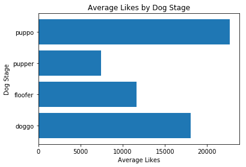

```python
plt.barh(['doggo', 'floofer', 'pupper', 'puppo'], dog_like)
plt.xlabel('Average Likes')
plt.ylabel('Dog Stage')
plt.title('Average Likes by Dog Stage');
```

## Which dog stage has the average highest rating?

```python
dogs_df
```

|  | tweet_id | text | rating_numerator | rating_denominator | dog_name | day | month | year | dog_stage | jpg_url | ... | p2_conf | p2_dog | p3 | p3_conf | p3_dog | retweet_count | favorite_count | created_at | retweeted | retweeted_status |
| --- | --- | --- | --- | --- | --- | --- | --- | --- | --- | --- | --- | --- | --- | --- | --- | --- | --- | --- | --- | --- | --- |
| 1759 | 832998151111966721 | This is Rhino. He arrived at a shelter with an... | 13 | 10 | Rhino | 18 | 2 | 2017 | doggo | https://pbs.twimg.com/media/C49nZavUYAEJjGw.jpg | ... | 0.317617 | True | bull_mastiff | 0.093928 | True | 2522 | 14549 | Sat Feb 18 17:00:10 +0000 2017 | False | NaN |
| 1760 | 775364825476165632 | This is Finley. He's an independent doggo stil... | 11 | 10 | Finley | 12 | 9 | 2016 | doggo | https://pbs.twimg.com/media/CsKmMB2WAAAXcAy.jpg | ... | 0.175257 | True | Pembroke | 0.034306 | True | 3472 | 8295 | Mon Sep 12 16:05:54 +0000 2016 | False | NaN |
| 1761 | 760521673607086080 | Doggo want what doggo cannot have. Temptation ... | 12 | 10 | None | 2 | 8 | 2016 | doggo | NaN | ... | NaN | NaN | NaN | NaN | NaN | 1608 | 4681 | Tue Aug 02 17:04:31 +0000 2016 | False | NaN |
| 1762 | 756526248105566208 | All hail sky doggo. 13/10 would jump super hig... | 13 | 10 | None | 22 | 7 | 2016 | doggo | https://pbs.twimg.com/media/Cn-4m2CXYAErPGe.jpg | ... | 0.004673 | False | fountain | 0.001234 | False | 4169 | 11506 | Fri Jul 22 16:28:07 +0000 2016 | False | NaN |
| 1763 | 832273440279240704 | Say hello to Smiley. He's a blind therapy dogg... | 14 | 10 | Smiley | 16 | 2 | 2017 | doggo | https://pbs.twimg.com/ext_tw_video_thumb/83227... | ... | 0.051928 | False | pug | 0.044311 | True | 2673 | 12385 | Thu Feb 16 17:00:25 +0000 2017 | False | NaN |
| 1764 | 832032802820481025 | This is Miguel. He was the only remaining dogg... | 12 | 10 | Miguel | 16 | 2 | 2017 | doggo | https://pbs.twimg.com/media/C4v5a4UWcAIRygc.jpg | ... | 0.152662 | True | Italian_greyhound | 0.135055 | True | 4746 | 13887 | Thu Feb 16 01:04:13 +0000 2017 | False | NaN |
| 1765 | 831939777352105988 | This is Emanuel. He's a h*ckin rare doggo. Dwe... | 12 | 10 | Emanuel | 15 | 2 | 2017 | doggo | https://pbs.twimg.com/media/C4uk0EWWQAAaZm1.jpg | ... | 0.091234 | False | grey_fox | 0.090644 | False | 7031 | 26404 | Wed Feb 15 18:54:34 +0000 2017 | False | NaN |
| 1766 | 719991154352222208 | This doggo was initially thrilled when she saw... | 10 | 10 | None | 12 | 4 | 2016 | doggo | https://pbs.twimg.com/media/Cf3sH62VAAA-LiP.jpg | ... | 0.130948 | True | Labrador_retriever | 0.094692 | True | 1979 | 5281 | Tue Apr 12 20:50:42 +0000 2016 | False | NaN |
| 1767 | 845397057150107648 | Say hello to Mimosa. She's an emotional suppor... | 13 | 10 | Mimosa | 24 | 3 | 2017 | doggo | https://pbs.twimg.com/media/C7t0IzLWkAINoft.jpg | ... | 0.186537 | True | West_Highland_white_terrier | 0.181985 | True | 2072 | 8241 | Fri Mar 24 22:08:59 +0000 2017 | False | NaN |
| 1768 | 796484825502875648 | Here's a sleepy doggo that requested some assi... | 12 | 10 | None | 9 | 11 | 2016 | doggo | https://pbs.twimg.com/media/Cw2uty8VQAAB0pL.jpg | ... | 0.107511 | False | Australian_terrier | 0.099843 | True | 2042 | 8472 | Wed Nov 09 22:49:15 +0000 2016 | False | NaN |
| 1769 | 831322785565769729 | This is Pete. He has no eyes. Needs a guide do... | 12 | 10 | Pete | 14 | 2 | 2017 | doggo | https://pbs.twimg.com/media/C4lzqQ4UEAApzU0.jpg | ... | 0.000046 | True | guinea_pig | 0.000041 | False | 1744 | 10042 | Tue Feb 14 02:02:51 +0000 2017 | False | NaN |
| 1770 | 750011400160841729 | Meet Piper. She's an airport doggo. Please ret... | 11 | 10 | Piper | 4 | 7 | 2016 | doggo | https://pbs.twimg.com/media/CmfmvGUWgAAuVKD.jpg | ... | 0.087150 | True | sombrero | 0.068510 | False | 1035 | 3568 | Mon Jul 04 17:00:26 +0000 2016 | False | NaN |
| 1771 | 775733305207554048 | This is Anakin. He strives to reach his full d... | 11 | 10 | Anakin | 13 | 9 | 2016 | doggo | https://pbs.twimg.com/media/CsP1UvaW8AExVSA.jpg | ... | 0.029473 | False | rhinoceros_beetle | 0.027806 | False | 4627 | 15413 | Tue Sep 13 16:30:07 +0000 2016 | False | NaN |
| 1772 | 782747134529531904 | This is Deacon. He's the happiest almost dry d... | 11 | 10 | Deacon | 3 | 10 | 2016 | doggo | https://pbs.twimg.com/media/CtzgXgeXYAA1Gxw.jpg | ... | 0.199482 | True | clumber | 0.040682 | True | 1604 | 8310 | Mon Oct 03 01:00:34 +0000 2016 | False | NaN |
| 1773 | 846514051647705089 | This is Barney. He's an elder doggo. Hitches a... | 13 | 10 | Barney | 28 | 3 | 2017 | doggo | https://pbs.twimg.com/media/C79sB4xXwAEvwKY.jpg | ... | 0.065199 | True | Norfolk_terrier | 0.052955 | True | 13076 | 48410 | Tue Mar 28 00:07:32 +0000 2017 | False | NaN |
| 1774 | 768193404517830656 | Meet Gerald. He's a fairly exotic doggo. Floof... | 8 | 10 | Gerald | 23 | 8 | 2016 | doggo | https://pbs.twimg.com/media/Cqkr0wiW8AAn2Oi.jpg | ... | 0.300851 | False | cheetah | 0.094474 | False | 4080 | 12157 | Tue Aug 23 21:09:14 +0000 2016 | False | NaN |
| 1775 | 829449946868879360 | Here's a stressed doggo. Had a long day. Many ... | 11 | 10 | None | 8 | 2 | 2017 | doggo | https://pbs.twimg.com/media/C4LMUf8WYAkWz4I.jpg | ... | 0.153210 | True | Pekinese | 0.132791 | True | 2329 | 11519 | Wed Feb 08 22:00:52 +0000 2017 | False | NaN |
| 1776 | 819006400881917954 | This is Sunny. She was also a very good First ... | 14 | 10 | Sunny | 11 | 1 | 2017 | doggo | NaN | ... | NaN | NaN | NaN | NaN | NaN | 21794 | 49960 | Wed Jan 11 02:21:57 +0000 2017 | False | NaN |
| 1777 | 757393109802180609 | Here's a doggo completely oblivious to the dou... | 10 | 10 | None | 25 | 7 | 2016 | doggo | https://pbs.twimg.com/media/CoLNAq6WAAAkmdJ.jpg | ... | 0.112676 | True | Rottweiler | 0.048039 | True | 2009 | 6462 | Mon Jul 25 01:52:43 +0000 2016 | False | NaN |
| 1778 | 735256018284875776 | This is Kellogg. He accidentally opened the fr... | 8 | 10 | Kellogg | 24 | 5 | 2016 | doggo | https://pbs.twimg.com/media/CjQnclkVEAA4pnK.jpg | ... | 0.351104 | True | doormat | 0.028075 | False | 993 | 3675 | Tue May 24 23:47:49 +0000 2016 | False | NaN |
| 1779 | 755206590534418437 | This is one of the most inspirational stories ... | 14 | 10 | None | 19 | 7 | 2016 | doggo | https://pbs.twimg.com/media/CnsIT0WWcAAul8V.jpg | ... | 0.008600 | False | carton | 0.004533 | False | 6148 | 18212 | Tue Jul 19 01:04:16 +0000 2016 | False | NaN |
| 1780 | 752334515931054080 | Here's a doggo trying to catch some fish. 8/10... | 8 | 10 | None | 11 | 7 | 2016 | doggo | https://pbs.twimg.com/ext_tw_video_thumb/75233... | ... | 0.086425 | True | wire-haired_fox_terrier | 0.075231 | True | 1263 | 4238 | Mon Jul 11 02:51:40 +0000 2016 | False | NaN |
| 1781 | 745433870967832576 | This is Lenox. She's in a wheelbarrow. Silly d... | 10 | 10 | Lenox | 22 | 6 | 2016 | doggo | https://pbs.twimg.com/media/ClhQJUUWAAEVpBX.jpg | ... | 0.000014 | True | wok | 0.000006 | False | 2894 | 7824 | Wed Jun 22 01:50:58 +0000 2016 | False | NaN |
| 1782 | 752660715232722944 | Hooman used Pokeball\n*wiggle*\n*wiggle*\nDogg... | 10 | 10 | None | 12 | 7 | 2016 | doggo | https://pbs.twimg.com/media/CnH87L6XYAAF7I_.jpg | ... | 0.050512 | True | basset | 0.049093 | True | 1794 | 4878 | Tue Jul 12 00:27:52 +0000 2016 | False | NaN |
| 1783 | 748932637671223296 | Say hello to Divine Doggo. Must be magical af.... | 13 | 10 | Divine | 1 | 7 | 2016 | doggo | https://pbs.twimg.com/media/CmS-QkQWAAAkUa-.jpg | ... | 0.204082 | True | English_setter | 0.021032 | True | 2564 | 6461 | Fri Jul 01 17:33:49 +0000 2016 | False | NaN |
| 1784 | 716080869887381504 | Here's a super majestic doggo and a sunset 11/... | 11 | 10 | None | 2 | 4 | 2016 | doggo | https://pbs.twimg.com/media/CfAHv83UMAIEQYx.jpg | ... | 0.254717 | True | Tibetan_mastiff | 0.071732 | True | 1935 | 5272 | Sat Apr 02 01:52:38 +0000 2016 | False | NaN |
| 1785 | 869596645499047938 | This is Scout. He just graduated. Officially a... | 12 | 10 | Scout | 30 | 5 | 2017 | doggo | https://pbs.twimg.com/media/DBFtiYqWAAAsjj1.jpg | ... | 0.008054 | True | muzzle | 0.006296 | False | 3327 | 16476 | Tue May 30 16:49:31 +0000 2017 | False | NaN |
| 1786 | 748692773788876800 | That is Quizno. This is his beach. He does not... | 10 | 10 | None | 1 | 7 | 2016 | doggo | https://pbs.twimg.com/media/CmPkGhFXEAABO1n.jpg | ... | 0.269287 | False | oxcart | 0.245653 | False | 1504 | 4659 | Fri Jul 01 01:40:41 +0000 2016 | False | NaN |
| 1787 | 871102520638267392 | Never doubt a doggo 14/10 https://t.co/AbBLh2FZCH | 14 | 10 | None | 3 | 6 | 2017 | doggo | NaN | ... | NaN | NaN | NaN | NaN | NaN | 5764 | 21461 | Sat Jun 03 20:33:19 +0000 2017 | False | NaN |
| 1788 | 871515927908634625 | This is Napolean. He's a Raggedy East Nicaragu... | 12 | 10 | Napolean | 4 | 6 | 2017 | doggo | https://pbs.twimg.com/media/DBg_HT9WAAEeIMM.jpg | ... | 0.020041 | True | swab | 0.003228 | False | 3628 | 20730 | Sun Jun 04 23:56:03 +0000 2017 | False | NaN |
| ... | ... | ... | ... | ... | ... | ... | ... | ... | ... | ... | ... | ... | ... | ... | ... | ... | ... | ... | ... | ... | ... |
| 2065 | 676617503762681856 | I promise this wasn't meant to be a cuteness o... | 13 | 10 | None | 15 | 12 | 2015 | pupper | https://pbs.twimg.com/media/CWPUB9TWwAALPPx.jpg | ... | 0.120530 | True | Pekinese | 0.006600 | True | 1108 | 3149 | Tue Dec 15 04:19:18 +0000 2015 | False | NaN |
| 2066 | 675113801096802304 | Meet Zuzu. He just graduated college. Astute p... | 10 | 10 | Zuzu | 11 | 12 | 2015 | pupper | https://pbs.twimg.com/media/CV58a4nXAAApywo.jpg | ... | 0.108807 | False | joystick | 0.043312 | False | 877 | 2120 | Fri Dec 11 00:44:07 +0000 2015 | False | NaN |
| 2067 | 688894073864884227 | This is Hamrick. He's covered in corn flakes. ... | 7 | 10 | Hamrick | 18 | 1 | 2016 | pupper | https://pbs.twimg.com/media/CY9xf1dUAAE4XLc.jpg | ... | 0.077347 | False | hamster | 0.062398 | False | 792 | 2462 | Mon Jan 18 01:22:00 +0000 2016 | False | NaN |
| 2068 | 702598099714314240 | This is Sansa. She's gotten too big for her ch... | 11 | 10 | Sansa | 24 | 2 | 2016 | pupper | https://pbs.twimg.com/media/CcAhPevW8AAoknv.jpg | ... | 0.133584 | False | Siamese_cat | 0.074440 | False | 3712 | 11332 | Wed Feb 24 20:56:55 +0000 2016 | False | NaN |
| 2069 | 687818504314159109 | With great pupper comes great responsibility. ... | 12 | 10 | None | 15 | 1 | 2016 | pupper | https://pbs.twimg.com/media/CYufR8_WQAAWCqo.jpg | ... | 0.060924 | True | toy_poodle | 0.017031 | True | 1080 | 2758 | Fri Jan 15 02:08:05 +0000 2016 | False | NaN |
| 2070 | 886366144734445568 | This is Roscoe. Another pupper fallen victim t... | 12 | 10 | Roscoe | 15 | 7 | 2017 | pupper | https://pbs.twimg.com/media/DE0BTnQUwAApKEH.jpg | ... | 0.000361 | True | Boston_bull | 0.000076 | True | 3316 | 21524 | Sat Jul 15 23:25:31 +0000 2017 | False | NaN |
| 2071 | 825026590719483904 | Say hello to Pablo. He's one gorgeous puppo. A... | 12 | 10 | Pablo | 27 | 1 | 2017 | puppo | https://pbs.twimg.com/media/C3MVTeHWcAAGNfx.jpg | ... | 0.467678 | True | malamute | 0.004976 | True | 1483 | 7020 | Fri Jan 27 17:04:02 +0000 2017 | False | NaN |
| 2072 | 825535076884762624 | Here's a very loving and accepting puppo. Appe... | 14 | 10 | None | 29 | 1 | 2017 | puppo | https://pbs.twimg.com/media/C3TjvitXAAAI-QH.jpg | ... | 0.147940 | True | black-and-tan_coonhound | 0.024525 | True | 19669 | 56413 | Sun Jan 29 02:44:34 +0000 2017 | False | NaN |
| 2073 | 889531135344209921 | This is Stuart. He's sporting his favorite fan... | 13 | 10 | Stuart | 24 | 7 | 2017 | puppo | https://pbs.twimg.com/media/DFg_2PVW0AEHN3p.jpg | ... | 0.013834 | True | redbone | 0.007958 | True | 2321 | 15359 | Mon Jul 24 17:02:04 +0000 2017 | False | NaN |
| 2074 | 867421006826221569 | This is Shikha. She just watched you drop a sk... | 12 | 10 | Shikha | 24 | 5 | 2017 | puppo | https://pbs.twimg.com/media/DAmyy8FXYAIH8Ty.jpg | ... | 0.381330 | True | malamute | 0.001670 | True | 2697 | 16755 | Wed May 24 16:44:18 +0000 2017 | False | NaN |
| 2075 | 784183165795655680 | This is Reginald. He's one magical puppo. Aero... | 12 | 10 | Reginald | 7 | 10 | 2016 | puppo | NaN | ... | NaN | NaN | NaN | NaN | NaN | 9374 | 22513 | Fri Oct 07 00:06:50 +0000 2016 | False | NaN |
| 2076 | 756275833623502848 | When ur older siblings get to play in the deep... | 10 | 10 | None | 21 | 7 | 2016 | puppo | https://pbs.twimg.com/media/Cn7U2xlW8AI9Pqp.jpg | ... | 0.086981 | True | bloodhound | 0.086276 | True | 1738 | 7114 | Thu Jul 21 23:53:04 +0000 2016 | False | NaN |
| 2077 | 743253157753532416 | This is Kilo. He cannot reach the snackum. Nif... | 10 | 10 | Kilo | 16 | 6 | 2016 | puppo | https://pbs.twimg.com/media/ClCQzFUUYAA5vAu.jpg | ... | 0.368137 | True | Eskimo_dog | 0.177822 | True | 1366 | 4624 | Thu Jun 16 01:25:36 +0000 2016 | False | NaN |
| 2078 | 803773340896923648 | This is Diogi. He fell in the pool as soon as ... | 12 | 10 | Diogi | 30 | 11 | 2016 | puppo | https://pbs.twimg.com/media/CyeTku-XcAALkBd.jpg | ... | 0.059707 | True | Irish_terrier | 0.034195 | True | 3220 | 11203 | Wed Nov 30 01:31:12 +0000 2016 | False | NaN |
| 2079 | 819952236453363712 | This is Oliver. He has dreams of being a servi... | 13 | 10 | Oliver | 13 | 1 | 2017 | puppo | https://pbs.twimg.com/media/C2EONHNWQAUWxkP.jpg | ... | 0.036221 | True | Italian_greyhound | 0.020412 | True | 1369 | 5927 | Fri Jan 13 17:00:21 +0000 2017 | False | NaN |
| 2080 | 790946055508652032 | This is Betty. She's assisting with the dishes... | 12 | 10 | Betty | 25 | 10 | 2016 | puppo | NaN | ... | NaN | NaN | NaN | NaN | NaN | 5496 | 18601 | Tue Oct 25 16:00:09 +0000 2016 | False | NaN |
| 2081 | 802239329049477120 | This is Loki. He'll do your taxes for you. Can... | 12 | 10 | Loki | 25 | 11 | 2016 | puppo | https://pbs.twimg.com/media/CyIgaTEVEAA-9zS.jpg | ... | 0.335774 | True | malamute | 0.134589 | True | 3040 | 10132 | Fri Nov 25 19:55:35 +0000 2016 | False | NaN |
| 2082 | 744995568523612160 | This is Abby. She got her face stuck in a glas... | 9 | 10 | Abby | 20 | 6 | 2016 | puppo | https://pbs.twimg.com/media/ClbBg4WWEAMjwJu.jpg | ... | 0.146336 | True | Tibetan_terrier | 0.134269 | True | 716 | 3277 | Mon Jun 20 20:49:19 +0000 2016 | False | NaN |
| 2083 | 874012996292530176 | This is Sebastian. He can't see all the colors... | 13 | 10 | Sebastian | 11 | 6 | 2017 | puppo | https://pbs.twimg.com/media/DCEeLxjXsAAvNSM.jpg | ... | 0.116622 | True | kelpie | 0.049182 | True | 11007 | 35501 | Sun Jun 11 21:18:31 +0000 2017 | False | NaN |
| 2084 | 859607811541651456 | Sorry for the lack of posts today. I came home... | 13 | 10 | None | 3 | 5 | 2017 | puppo | https://pbs.twimg.com/media/C-3wvtxXcAUTuBE.jpg | ... | 0.024099 | True | Labrador_retriever | 0.019285 | True | 1704 | 19476 | Wed May 03 03:17:27 +0000 2017 | False | NaN |
| 2085 | 780931614150983680 | I want to finally rate this iconic puppo who t... | 13 | 10 | None | 28 | 9 | 2016 | puppo | https://pbs.twimg.com/media/CtZtJxAXEAAyPGd.jpg | ... | 0.065462 | False | chain | 0.036469 | False | 8536 | 24192 | Wed Sep 28 00:46:20 +0000 2016 | False | NaN |
| 2086 | 752519690950500352 | Hopefully this puppo on a swing will help get ... | 11 | 10 | None | 11 | 7 | 2016 | puppo | https://pbs.twimg.com/media/CnF8qVDWYAAh0g1.jpg | ... | 0.000010 | True | Eskimo_dog | 0.000001 | True | 3917 | 8157 | Mon Jul 11 15:07:30 +0000 2016 | False | NaN |
| 2087 | 738537504001953792 | This is Bayley. She fell asleep trying to esca... | 11 | 10 | Bayley | 3 | 6 | 2016 | puppo | https://pbs.twimg.com/media/Cj_P7rSUgAAYQbz.jpg | ... | 0.028942 | False | Pembroke | 0.026498 | True | 1759 | 5575 | Fri Jun 03 01:07:16 +0000 2016 | False | NaN |
| 2088 | 787717603741622272 | This is Tonks. She is a service puppo. Can hea... | 13 | 10 | Tonks | 16 | 10 | 2016 | puppo | https://pbs.twimg.com/media/Cu6I9vvWIAAZG0a.jpg | ... | 0.004920 | True | kelpie | 0.000853 | True | 3240 | 11416 | Sun Oct 16 18:11:26 +0000 2016 | False | NaN |
| 2089 | 822872901745569793 | Here's a super supportive puppo participating ... | 13 | 10 | None | 21 | 1 | 2017 | puppo | https://pbs.twimg.com/media/C2tugXLXgAArJO4.jpg | ... | 0.160329 | True | Irish_terrier | 0.069126 | True | 48265 | 132810 | Sat Jan 21 18:26:02 +0000 2017 | False | NaN |
| 2090 | 878776093423087618 | This is Snoopy. He's a proud #PrideMonthPuppo.... | 13 | 10 | Snoopy | 25 | 6 | 2017 | puppo | https://pbs.twimg.com/media/DDIKMXzW0AEibje.jpg | ... | 0.150487 | True | Ibizan_hound | 0.039725 | True | 4319 | 19763 | Sun Jun 25 00:45:22 +0000 2017 | False | NaN |
| 2091 | 751132876104687617 | This is Cooper. He's just so damn happy. 10/10... | 10 | 10 | Cooper | 7 | 7 | 2016 | puppo | https://pbs.twimg.com/media/CmyPXNOW8AEtaJ-.jpg | ... | 0.038254 | True | golden_retriever | 0.007610 | True | 1480 | 5610 | Thu Jul 07 19:16:47 +0000 2016 | False | NaN |
| 2092 | 889665388333682689 | Here's a puppo that seems to be on the fence a... | 13 | 10 | None | 25 | 7 | 2017 | puppo | https://pbs.twimg.com/media/DFi579UWsAAatzw.jpg | ... | 0.027356 | True | basenji | 0.004633 | True | 8538 | 38818 | Tue Jul 25 01:55:32 +0000 2017 | False | NaN |
| 2093 | 793195938047070209 | Say hello to Lily. She's pupset that her costu... | 12 | 10 | Lily | 31 | 10 | 2016 | puppo | https://pbs.twimg.com/media/CwH_foYWgAEvTyI.jpg | ... | 0.074100 | True | Chihuahua | 0.042339 | True | 6547 | 17063 | Mon Oct 31 21:00:23 +0000 2016 | False | NaN |
| 2094 | 855851453814013952 | Here's a puppo participating in the #ScienceMa... | 13 | 10 | None | 22 | 4 | 2017 | puppo | https://pbs.twimg.com/media/C-CYWrvWAAU8AXH.jpg | ... | 0.115138 | True | groenendael | 0.096100 | True | 19196 | 47844 | Sat Apr 22 18:31:02 +0000 2017 | False | NaN |

336 rows × 25 columns

```python
dog_ratings = dogs_df.groupby('dog_stage', as_index=True).rating_numerator.mean()
```

```python
dog_ratings
```

```
dog_stage
doggo      11.847222
floofer    11.800000
pupper     10.747826
puppo      12.041667
Name: rating_numerator, dtype: float64
```

### Visualization

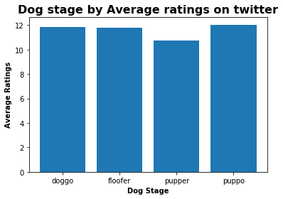

```python
plt.bar(['doggo', 'floofer', 'pupper', 'puppo'], dog_ratings)
plt.title('Dog stage by Average ratings on twitter',weight='bold', fontsize=16)
plt.xlabel('Dog Stage',weight='bold')
plt.ylabel('Average Ratings', weight='bold');
```

## Which dog stage is most tweeted about?

```python
dogs_df.groupby('dog_stage').tweet_id.count()
```

```
dog_stage
doggo       72
floofer     10
pupper     230
puppo       24
Name: tweet_id, dtype: int64
```

### Visualization

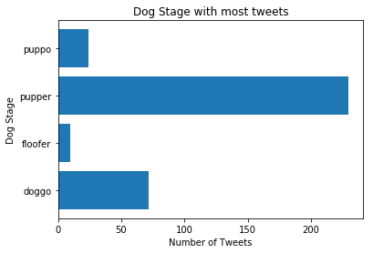

```python
plt.barh(['doggo', 'floofer', 'pupper', 'puppo'],
       dogs_df.groupby('dog_stage').tweet_id.count())
plt.title('Dog Stage with most tweets')
plt.xlabel('Number of Tweets')
plt.ylabel('Dog Stage');
```